# Hyperspectral Imaging Data

## Absract

Remote sensing involves understanding activities on surface of the earth based on the reflected light from the surface. Devices which help us get this information are the cameras on board satellites, Surveillance planes/ UAVs/Drones. There are multiple methods of collecting information of activities of surface of the earth as mentioned in https://en.wikipedia.org/wiki/Remote_sensing. Hyper spectral imaging is one of the method which help us peek into the unseen light by collecting signals of multiple narrow bands of wavelength beyond visible light spectrum.

In remote sensing, hyperspectral images help study surface of the earth. It captures unique information associated with specific activity or structures (natural or human) on the surface. This can help Agriculture, Minerals Exploration, Defense,Surveillance etc. These images can help monitor Earths surface activity.

Based on the image data we can segment the areas of our interest. With image and segmented data we can train a Deep Learning algorithm which can in future generate segmented image from a raw image.

## Problem

At the present we have limited data available to train a DL model to make segmentation of any given patch of earth's surface based on the hyperspectral image. For study purpose there are images collected through airbornes or satellites. The data set is available in the link - http://www.ehu.eus/ccwintco/index.php/Hyperspectral_Remote_Sensing_Scenes#Indian_Pines

The scene was gathered by AVIRIS sensor over the Indian Pines test site in North-western Indiana and consists of 145x145 pixels and 224 spectral reflectance bands in the wavelength range 0.4–2.5 10^(-6) meters. This scene is a subset of a larger one.

The ground truth available is designated into 16 classes and is not all mutually exclusive. The number of bands are reduced to 200 by removing bands covering the region of water absorption. (In the same link we can observe other patchs of HS images, which can be explored for study)

Now we have to come up with system that should be able to segment the regions based on the available Hyper Spectral(HS) image data.

Deep Learning is one of the techniques which can predict classification of specific data based on the information associated with data. Deeplearning invovles different kinds of Neural Network architecture to be built and trained on the data.

Refer the blog in the link mentioned, which captures overview of simple to complex neural network architectures - https://www.sabrepc.com/blog/Deep-Learning-and-AI/6-types-of-neural-networks-to-know-about

### Module imports

```python
import scipy.io
import matplotlib.pyplot as plt
import numpy as np
import pandas as pd
import seaborn as sb
from sklearn.model_selection import train_test_split
import tensorflow as tf
from tensorflow.keras.layers import Input
from tensorflow.keras.layers import Dense,Dropout
from tensorflow.keras.layers import Flatten
from tensorflow.keras.losses import categorical_crossentropy
from tensorflow.keras import Model, initializers, regularizers
from tensorflow.keras.utils import plot_model, to_categorical
from sklearn.metrics import f1_score,roc_auc_score
from tensorflow.keras.callbacks import ModelCheckpoint
from tensorflow.keras.callbacks import EarlyStopping,ReduceLROnPlateau
from tensorflow.keras.callbacks import LearningRateScheduler
import time, os
from tensorflow.python.keras.callbacks import TensorBoard
from datetime import datetime
from sklearn.preprocessing import MinMaxScaler, StandardScaler
from sklearn.utils import class_weight
from sklearn.metrics import confusion_matrix, cohen_kappa_score
from tensorflow.keras import optimizers
```

```python
# Data Source : http://www.ehu.eus/ccwintco/index.php/Hyperspectral_Remote_Sensing_Scenes#Indian_Pines
!wget wget --header="Host: www.ehu.eus" --header="User-Agent: Mozilla/5.0 (Windows NT 10.0; Win64; x64) AppleWebKit/537.36 (KHTML, like Gecko) Chrome/97.0.4692.71 Safari/537.36" --header="Accept: text/html,application/xhtml+xml,application/xml;q=0.9,image/avif,image/webp,image/apng,*/*;q=0.8,application/signed-exchange;v=b3;q=0.9" --header="Accept-Language: en-US,en;q=0.9" --header="Referer: http://www.ehu.eus/ccwintco/index.php/Hyperspectral_Remote_Sensing_Scenes" "http://www.ehu.eus/ccwintco/uploads/6/67/Indian_pines_corrected.mat" -c -O 'Indian_pines_corrected.mat'
!unzip Indian_pines_corrected.mat
```

[output not shown]

```python
# mat = scipy.io.loadmat('HSI_Data\Indian_pines_corrected.mat')
mat = scipy.io.loadmat('Indian_pines_corrected.mat')
```

## Indian pines Image data

#### Shape

```python
mat['indian_pines_corrected'].shape
```

```
(145, 145, 200)
```

#### Image

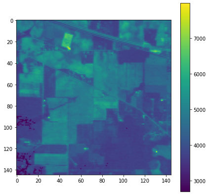

```python
plt.figure(figsize=(7,7))
plt.imshow(mat['indian_pines_corrected'][:,:,10])
plt.colorbar()
plt.show()
```

#### Information in one Pixel

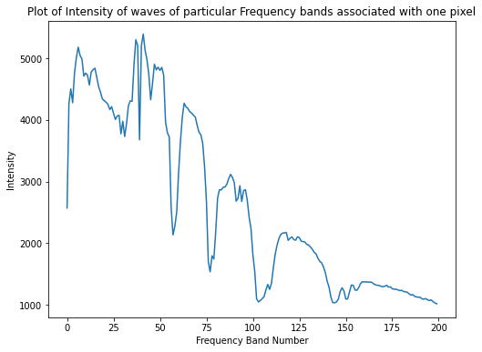

```python
plt.figure(figsize=(8,6))
plt.plot(mat['indian_pines_corrected'][1,20,:])
plt.title('Plot of Intensity of waves of particular Frequency bands associated with one pixel')
plt.xlabel('Frequency Band Number')
plt.ylabel('Intensity')
plt.show()
```

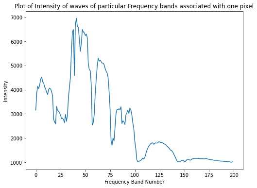

```python
plt.figure(figsize=(8,6))
plt.plot(mat['indian_pines_corrected'][20,30,:])
plt.title('Plot of Intensity of waves of particular Frequency bands associated with one pixel')
plt.xlabel('Frequency Band Number')
plt.ylabel('Intensity')
plt.show()
```

```python
np.max(mat['indian_pines_corrected']), np.min(mat['indian_pines_corrected'])
```

```
(9604, 955)
```

#### Ground Truth image

```python
# mat_gt = scipy.io.loadmat('HSI_Data\Indian_pines_gt.mat')
mat_gt = scipy.io.loadmat('Indian_pines_gt.mat')
```

```python
mat_gt['indian_pines_gt'][25:40,15:30]
```

```
array([[ 2,  2,  2,  2,  2,  2,  0,  0,  0,  0,  0, 15, 15, 15, 15],
       [ 2,  2,  2,  2,  2,  2,  0,  0,  0,  0,  0, 15, 15, 15, 15],
       [ 0,  0,  0,  0,  0,  0,  0,  0,  0,  0, 15, 15, 15, 15, 15],
       [ 0,  0,  0,  0,  0,  0,  0,  0,  0,  0,  0,  0,  0,  0,  0],
       [ 0,  0,  0,  0,  0,  0,  0,  0,  0,  0,  0,  0,  0,  0,  0],
       [ 3,  3,  3,  3,  3,  3,  3,  3,  3,  0,  0,  2,  2,  2,  2],
       [ 3,  3,  3,  3,  3,  3,  3,  3,  3,  0,  0,  2,  2,  2,  2],
       [ 3,  3,  3,  3,  3,  3,  3,  3,  3,  0,  0,  2,  2,  2,  2],
       [ 3,  3,  3,  3,  3,  3,  3,  3,  3,  0,  0,  2,  2,  2,  2],
       [ 3,  3,  3,  3,  3,  3,  3,  3,  3,  0,  0,  2,  2,  2,  2],
       [ 0,  0,  3,  3,  3,  3,  3,  3,  3,  0,  0,  2,  2,  2,  2],
       [ 4,  0,  0,  0,  3,  3,  3,  3,  3,  0,  0,  2,  2,  2,  2],
       [ 4,  4,  0,  0,  0,  0,  3,  3,  3,  0,  0,  2,  2,  2,  2],
       [ 4,  4,  0,  0,  0,  0,  0,  0,  3,  0,  0,  2,  2,  2,  2],
       [ 4,  4,  0,  0,  0,  0,  0,  0,  0,  0,  0,  2,  2,  2,  2]],
      dtype=uint8)
```

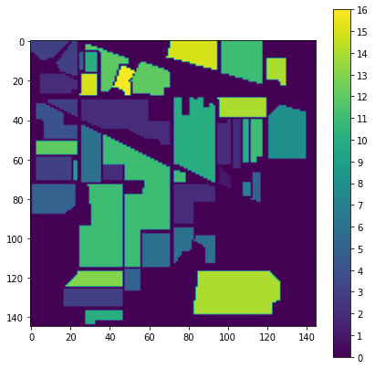

```python
plt.figure(figsize=(7,7))
plt.imshow(mat_gt['indian_pines_gt'])
plt.colorbar(ticks=range(0,17))
plt.show()
```

```python
mat_gt['indian_pines_gt'].shape
```

```
(145, 145)
```

## Pixelwise classification using Neural Network

Reshaping of the image (3 dimension - x,y,l) into rows and columns. Each row represents the each pixel at location(x,y). Each column represents the third dimension(l) which captures the intensity of different frequency bands.

```python
# https://panjeh.medium.com/convert-numpy-3d-array-to-2d-array-in-python-931a4cdf8b12
```

```python
mat_rshp = mat['indian_pines_corrected'].reshape(-1,200)
```

```python
mat_gt_rshp = mat_gt['indian_pines_gt'].reshape(-1,1)
```

```python
px_data_full = pd.DataFrame(mat_rshp)
```

```python
# px_class_data = pd.DataFrame(mat_gt_rshp)
```

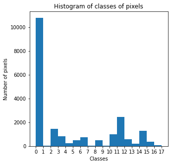

```python
# px_class_data.value_counts()
plt.figure(figsize=(5,5))
plt.hist(mat_gt_rshp,bins=range(0,18,1))
plt.xticks(range(0,18,1))
plt.title('Histogram of classes of pixels')
plt.xlabel('Classes')
plt.ylabel('Number of pixels')
plt.show()
```

Reshape verification

```python
# mat_rshp_chk = mat_rshp.reshape(145,145,200)
```

```python
# plt.imshow(mat_rshp_chk[:,:,20])
# plt.show()
```

```python
# mat_gt_rshp_chk = mat_gt_rshp.reshape(145,145)
```

```python
# plt.imshow(mat_gt_rshp_chk)
# plt.show()
```

### Pixelwise data

```python
px_data = pd.DataFrame(mat_rshp)
px_data
```

|  | 0 | 1 | 2 | 3 | 4 | 5 | 6 | 7 | 8 | 9 | 10 | 11 | 12 | 13 | 14 | 15 | 16 | 17 | 18 | 19 | 20 | 21 | 22 | 23 | 24 | 25 | 26 | 27 | 28 | … |
| --- | --- | --- | --- | --- | --- | --- | --- | --- | --- | --- | --- | --- | --- | --- | --- | --- | --- | --- | --- | --- | --- | --- | --- | --- | --- | --- | --- | --- | --- | --- |
| 0 | 3172 | 4142 | 4506 | 4279 | 4782 | 5048 | 5213 | 5106 | 5053 | 4750 | 4816 | 4769 | 4610 | 4805 | 4828 | 4861 | 4767 | 4624 | 4549 | 4463 | 4462 | 4446 | 4445 | 4336 | 4381 | 4319 | 4207 | 4305 | 4311 | … |
| 1 | 2580 | 4266 | 4502 | 4426 | 4853 | 5249 | 5352 | 5353 | 5347 | 5065 | 5141 | 5100 | 4994 | 5172 | 5290 | 5289 | 5217 | 5053 | 5033 | 4939 | 4931 | 4941 | 4902 | 4824 | 4859 | 4805 | 4698 | 4794 | 4806 | … |
| 2 | 3687 | 4266 | 4421 | 4498 | 5019 | 5293 | 5438 | 5427 | 5383 | 5132 | 5227 | 5172 | 5097 | 5313 | 5411 | 5412 | 5341 | 5191 | 5140 | 5069 | 5110 | 5119 | 5046 | 4981 | 5023 | 4987 | 4862 | 4965 | 4992 | … |
| 3 | 2749 | 4258 | 4603 | 4493 | 4958 | 5234 | 5417 | 5355 | 5349 | 5096 | 5147 | 5078 | 5040 | 5237 | 5321 | 5344 | 5255 | 5121 | 5035 | 4956 | 4994 | 4980 | 4905 | 4857 | 4900 | 4831 | 4720 | 4848 | 4847 | … |
| 4 | 2746 | 4018 | 4675 | 4417 | 4886 | 5117 | 5215 | 5096 | 5098 | 4834 | 4853 | 4857 | 4734 | 4879 | 4976 | 4958 | 4885 | 4754 | 4647 | 4532 | 4586 | 4591 | 4492 | 4453 | 4497 | 4398 | 4297 | 4408 | 4401 | … |
| ... | ... | ... | ... | ... | ... | ... | ... | ... | ... | ... | ... | ... | ... | ... | ... | ... | ... | ... | ... | ... | ... | ... | ... | ... | ... | ... | ... | ... | ... | … |
| 21020 | 2561 | 3987 | 4011 | 4023 | 4201 | 4377 | 4418 | 4248 | 4180 | 3838 | 3762 | 3696 | 3594 | 3750 | 3806 | 3764 | 3655 | 2611 | 3199 | 3036 | 2978 | 2837 | 2758 | 2650 | 2617 | 2494 | 2397 | 2366 | 2313 | … |
| 21021 | 2726 | 4104 | 4024 | 3880 | 4210 | 4377 | 4413 | 4174 | 4229 | 3900 | 3786 | 3696 | 3623 | 3726 | 3758 | 3725 | 3614 | 2584 | 3174 | 3042 | 2958 | 2837 | 2769 | 2626 | 2617 | 2484 | 2387 | 2362 | 2322 | … |
| 21022 | 3153 | 3864 | 4282 | 3889 | 4310 | 4372 | 4375 | 4208 | 4096 | 3878 | 3890 | 3683 | 3594 | 3714 | 3724 | 3700 | 2809 | 2564 | 3177 | 3031 | 2925 | 2837 | 2719 | 2605 | 2603 | 2476 | 2373 | 2335 | 2308 | … |
| 21023 | 3155 | 4104 | 4106 | 4027 | 4139 | 4318 | 4413 | 4174 | 4140 | 3933 | 3799 | 3627 | 2752 | 3667 | 3688 | 3628 | 2750 | 3245 | 3153 | 2967 | 2890 | 2830 | 2719 | 2583 | 2580 | 2480 | 2359 | 2339 | 2289 | … |
| 21024 | 3323 | 3860 | 4197 | 3952 | 4148 | 4279 | 4375 | 4225 | 3988 | 3866 | 3811 | 3639 | 3623 | 3686 | 3722 | 3673 | 2775 | 3315 | 3180 | 2984 | 2910 | 2837 | 2719 | 2614 | 2594 | 2494 | 2370 | 2352 | 2296 | … |

21025 rows × 200 columns

```python
px_class = pd.DataFrame(mat_gt_rshp)
px_class
```

|  | 0 |
| --- | --- |
| 0 | 3 |
| 1 | 3 |
| 2 | 3 |
| 3 | 3 |
| 4 | 3 |
| ... | ... |
| 21020 | 0 |
| 21021 | 0 |
| 21022 | 0 |
| 21023 | 0 |
| 21024 | 0 |

21025 rows × 1 columns

```python
# px_class[px_class[0]==0].index
```

```python
# px_data = px_data.drop(px_class[px_class[0]==0].index,axis=0)
```

```python
# px_class = px_class.drop(px_class[px_class[0]==0].index,axis=0)
```

```python
px_class[0].describe()
```

```
count    21025.000000
mean         4.224923
std          5.281972
min          0.000000
25%          0.000000
50%          0.000000
75%         10.000000
max         16.000000
Name: 0, dtype: float64
```

### Train and Test Split

```python
X_train, X_test, y_train, y_test = train_test_split(px_data, px_class, test_size=0.3, random_state=20, stratify=px_class)
```

```python
PX_class_train = y_train.reindex(px_data_full.index,fill_value=-1)
```

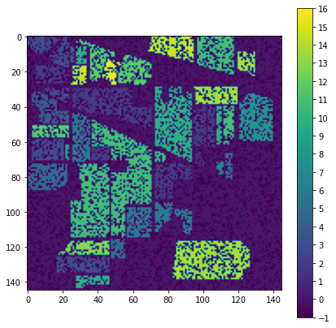

```python
plt.figure(figsize=(7,7))
plt.imshow(PX_class_train.to_numpy().reshape((145,145)))
plt.colorbar(ticks=range(-1,17,1))
plt.show()
```

```python
y_ctg_train = to_categorical(y_train)
y_ctg_test = to_categorical(y_test)
```

```python
# y_ctg_train = y_ctg_train[:,1:]
# y_ctg_test = y_ctg_test[:,1:]
```

### Feature Engineering

#### Standardization

```python
# Scaler = MinMaxScaler()
Scaler = StandardScaler()
X_train_std = pd.DataFrame(Scaler.fit_transform(X_train), index = X_train.index)
X_test_std = pd.DataFrame(Scaler.transform(X_test), index = X_test.index)
```

```python
y_train
```

|  | 0 |
| --- | --- |
| 7674 | 8 |
| 14004 | 0 |
| 17623 | 0 |
| 12672 | 11 |
| 15734 | 6 |
| ... | ... |
| 3002 | 0 |
| 14264 | 11 |
| 2104 | 0 |
| 7618 | 10 |
| 15062 | 0 |

14717 rows × 1 columns

#### Variance

```python
variance_data = X_train.var()
```

```python
variance_data
```

```
0      127297.253743
1       52361.818113
2       66493.685912
3       78627.459402
4      120039.036524
           ...
195       698.846583
196       885.827231
197       433.704496
198       129.637613
199        49.795652
Length: 200, dtype: float64
```

```python
min(variance_data)
```

```
49.79565233299031
```

```python
Feat_var_reject = variance_data[variance_data<0.01*variance_data.describe()['max']].index
Feat_var_reject
```

```
Int64Index([ 76,  77,  78,  79, 101, 102, 103, 104, 105, 106, 107, 109, 141,
            142, 143, 144, 145, 146, 147, 149, 150, 151, 152, 155, 156, 175,
            176, 177, 178, 179, 180, 181, 182, 183, 184, 185, 186, 187, 188,
            189, 190, 191, 192, 193, 194, 195, 196, 197, 198, 199],
           dtype='int64')
```

```python
X_train[Feat_var_reject]
```

|  | 76 | 77 | 78 | 79 | 101 | 102 | 103 | 104 | 105 | 106 | 107 | 109 | 141 | 142 | 143 | 144 | 145 | 146 | 147 | 149 | 150 | 151 | 152 | 155 | 156 | 175 | 176 | 177 | 178 | … |
| --- | --- | --- | --- | --- | --- | --- | --- | --- | --- | --- | --- | --- | --- | --- | --- | --- | --- | --- | --- | --- | --- | --- | --- | --- | --- | --- | --- | --- | --- | --- |
| 7674 | 1842 | 1676 | 1997 | 1884 | 1612 | 1095 | 1041 | 1060 | 1097 | 1112 | 1205 | 1233 | 1263 | 1126 | 1047 | 1025 | 1028 | 1059 | 1148 | 1167 | 1066 | 1070 | 1155 | 1174 | 1157 | 1184 | 1164 | 1154 | 1154 | … |
| 14004 | 1900 | 1686 | 1965 | 1874 | 1509 | 1090 | 1044 | 1052 | 1069 | 1065 | 1111 | 1137 | 1184 | 1080 | 1040 | 1015 | 1015 | 1045 | 1068 | 1080 | 1034 | 1042 | 1078 | 1085 | 1087 | 1114 | 1100 | 1094 | 1103 | … |
| 17623 | 1860 | 1678 | 1926 | 1821 | 1498 | 1059 | 1026 | 1046 | 1038 | 1050 | 1092 | 1104 | 1150 | 1063 | 1033 | 1010 | 1010 | 1018 | 1040 | 1049 | 1019 | 1016 | 1046 | 1059 | 1062 | 1086 | 1081 | 1069 | 1066 | … |
| 12672 | 1726 | 1552 | 1856 | 1762 | 1587 | 1120 | 1034 | 1070 | 1112 | 1133 | 1251 | 1278 | 1316 | 1154 | 1053 | 1040 | 1035 | 1116 | 1227 | 1258 | 1099 | 1098 | 1226 | 1257 | 1249 | 1274 | 1251 | 1239 | 1227 | … |
| 15734 | 1748 | 1579 | 1869 | 1753 | 1460 | 1085 | 1031 | 1038 | 1063 | 1060 | 1130 | 1144 | 1189 | 1088 | 1027 | 1011 | 1020 | 1051 | 1085 | 1107 | 1043 | 1053 | 1097 | 1113 | 1116 | 1134 | 1121 | 1105 | 1107 | … |
| ... | ... | ... | ... | ... | ... | ... | ... | ... | ... | ... | ... | ... | ... | ... | ... | ... | ... | ... | ... | ... | ... | ... | ... | ... | ... | ... | ... | ... | ... | … |
| 3002 | 1587 | 1437 | 1689 | 1596 | 1416 | 1066 | 1020 | 1040 | 1073 | 1079 | 1163 | 1177 | 1184 | 1090 | 1038 | 1030 | 1013 | 1059 | 1131 | 1151 | 1072 | 1065 | 1136 | 1160 | 1148 | 1163 | 1147 | 1142 | 1137 | … |
| 14264 | 1759 | 1585 | 1827 | 1778 | 1598 | 1087 | 1057 | 1084 | 1102 | 1128 | 1256 | 1260 | 1311 | 1138 | 1048 | 1035 | 1040 | 1101 | 1208 | 1231 | 1098 | 1087 | 1202 | 1237 | 1229 | 1264 | 1257 | 1233 | 1228 | … |
| 2104 | 1804 | 1613 | 1884 | 1755 | 1484 | 1084 | 1028 | 1048 | 1062 | 1079 | 1134 | 1162 | 1186 | 1093 | 1043 | 1010 | 1035 | 1048 | 1102 | 1122 | 1048 | 1045 | 1105 | 1122 | 1116 | 1140 | 1135 | 1117 | 1118 | … |
| 7618 | 1755 | 1619 | 1901 | 1839 | 1643 | 1102 | 1034 | 1086 | 1116 | 1147 | 1298 | 1306 | 1329 | 1163 | 1051 | 1049 | 1058 | 1131 | 1268 | 1296 | 1122 | 1126 | 1268 | 1291 | 1296 | 1322 | 1304 | 1300 | 1285 | … |
| 15062 | 1806 | 1604 | 1918 | 1802 | 1532 | 1094 | 1034 | 1058 | 1071 | 1080 | 1144 | 1152 | 1198 | 1085 | 1033 | 1006 | 1024 | 1034 | 1084 | 1093 | 1043 | 1042 | 1092 | 1113 | 1101 | 1136 | 1113 | 1120 | 1108 | … |

14717 rows × 50 columns

Note: Varince is not low (not close to zero). each feature might have distribution of their own. So we will not consider dropping features based on variance.

#### Correlation

```python
# correlation evaluation of filtered dataset
Correlation_mat = X_train_std.corr('pearson')
```

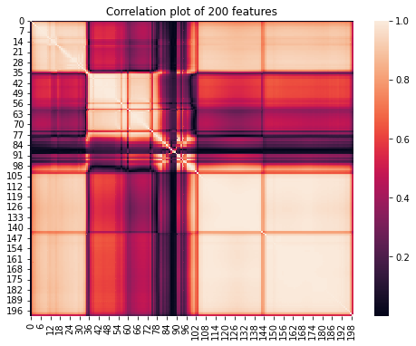

```python
# Correlation heatmap on subset of features. Example plot as the feature size is large.
plt.figure(figsize=(8,6))
sb.heatmap(abs(Correlation_mat))#.iloc[40:60,40:60]),annot=True)
plt.title('Correlation plot of 200 features')
plt.show()
```

If there were no correlation among features, there would be high correlation (white colored) only on the diagonal of the above figure.

```python
def get_corr_features(corr_mat):
    '''This function returns feature list which have correlation above 0.99 for a given correlation matrix'''
    # list to store correlated features
    feature_correlated = []
    for i in range(len(corr_mat)):
        for j in range(i) : #This loop repeats only till one step before j=i, Thus captures information from
                            #lower triangle matrix.
            if((corr_mat.iloc[i,j]>=0.99) and (corr_mat.columns[i] not in feature_correlated)):
                # features with correlation above 0.99 added to list.
                feature_correlated.append(corr_mat.columns[i])
    return feature_correlated
```

```python
# Correlation matrix of filtered train data passed to get_corr_features function to get list of features with high correlation.
feature_correlated = get_corr_features(Correlation_mat)
```

```python
len(feature_correlated)
```

```
105
```

```python
feature_correlated
```

```
[7,
 8,
 9,
 15,
 24,
 27,
 28,
 38,
 40,
 41,
 42,
 43,
 44,
 45,
 46,
 47,
 48,
 49,
 50,
 51,
 52,
 58,
 64,
 65,
 66,
 67,
 68,
 69,
 108,
 109,
 110,
 111,
 112,
 113,
 114,
 115,
 116,
 117,
 118,
 119,
```

[output cut: 50 more lines]

```
 176,
 177,
 178,
 179,
 180,
 181,
 182,
 183,
 184,
 185,
 186,
 187,
 188,
 189,
 190]
```

Dropping features with high correlation

```python
X_train_std = X_train_std.drop(feature_correlated, axis=1)
X_test_std = X_test_std.drop(feature_correlated, axis=1)
```

```python
X_train_std.shape, X_test_std.shape
```

```
((14717, 95), (6308, 95))
```

#### Class Weights Evaluation

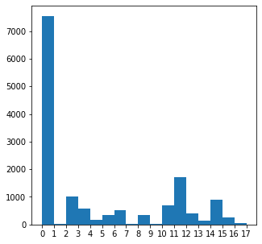

```python
plt.figure(figsize=(5,5))
plt.xticks(range(0,18,1))
plt.hist(y_train.to_numpy(),bins=range(0,18,1))
plt.show()
```

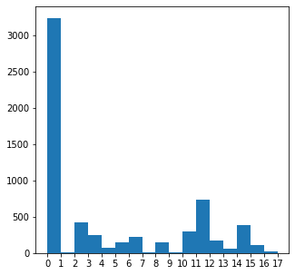

```python
plt.figure(figsize=(5,5))
plt.xticks(range(0,18,1))
plt.hist(y_test.to_numpy(),bins=range(0,18,1))
plt.show()
```

```python
y_train.shape
```

```
(14717, 1)
```

```python
np.squeeze(y_train.to_numpy()).shape
```

```
(14717,)
```

```python
# https://datascience.stackexchange.com/questions/13490/how-to-set-class-weights-for-imbalanced-classes-in-keras
# wts = n_samples / (n_classes * np.bincount(y))
# class_weights_1 = class_weight.compute_class_weight(class_weight='balanced',classes=np.unique(y_train),y=np.squeeze(y_train.to_numpy()))
```

```python
# class_wts_1 = dict(enumerate(class_weights_1/np.sum(class_weights_1)))
# class_wts_1
```

```python
# # Get the class weights for loss evaluation as the data has class imbalance
# https://medium.com/gumgum-tech/handling-class-imbalance-by-introducing-sample-weighting-in-the-loss-function-3bdebd8203b4
# https://neptune.ai/blog/keras-loss-functions
# https://keras.io/api/models/model_training_apis
class_count = y_train.value_counts().sort_index()
class_wts = 1/class_count
class_wts = class_wts/np.sum(class_wts)
class_wts = dict(enumerate(class_wts.to_list()))
class_wts
```

```
{0: 0.0006592993609901092,
 1: 0.15540922124838732,
 2: 0.0049730950799483946,
 3: 0.008559544027449904,
 4: 0.029958404096074667,
 5: 0.014713299053101758,
 6: 0.009732084305182768,
 7: 0.24865475399741974,
 8: 0.014845059940144461,
 9: 0.355221077139171,
 10: 0.0073133751175711685,
 11: 0.0028947002793646066,
 12: 0.011983361638429868,
 13: 0.03453538249964162,
 14: 0.00561931647451796,
 15: 0.018418870666475535,
 16: 0.07650915507612915}
```

```python
# class_wts.values()
```

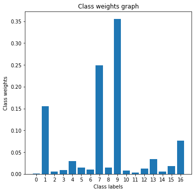

```python
plt.figure(figsize=(6,6))
plt.bar(range(0,17,1),list(class_wts.values()))
plt.xlabel('Class labels')
plt.xticks(range(0,17,1))
plt.ylabel('Class weights')
plt.title('Class weights graph')
plt.show()
```

```python
list(class_wts.values())
```

```
[0.0006592993609901092,
 0.15540922124838732,
 0.0049730950799483946,
 0.008559544027449904,
 0.029958404096074667,
 0.014713299053101758,
 0.009732084305182768,
 0.24865475399741974,
 0.014845059940144461,
 0.355221077139171,
 0.0073133751175711685,
 0.0028947002793646066,
 0.011983361638429868,
 0.03453538249964162,
 0.00561931647451796,
 0.018418870666475535,
 0.07650915507612915]
```

```python
np.argmax(list(class_wts.values()))
```

```
9
```

```python
np.argmin(list(class_wts.values()))
```

```
0
```

```python
sum(list(class_wts.values()))
```

```
1.0
```

```python
X_train_std.shape, y_ctg_train.shape
```

```
((14717, 95), (14717, 17))
```

```python
X_test_std.shape, y_ctg_test.shape
```

```
((6308, 95), (6308, 17))
```

```python
# y_ctg_train
```

### Neural network model

##### F1 score calculation callback function definition

```python
class metric_calc(tf.keras.callbacks.Callback):

    def on_train_begin(self, logs={}):
        ## on begin of training, we are creating a instance varible called metrics
        ## it is a dict with keys [loss, acc, val_loss, val_acc]
        self.metrics={'micro_F1_train': [],
                      'micro_F1_val': [],
                      'val_acc':[]}

    def on_epoch_end(self, epoch, logs={}):
        ## on end of each epoch, we will get logs and update the self.metrics dict

        # Training score
        y_true = y_train
        y_pred = self.model.predict(X_train_std)

        yp = np.argmax(y_pred,axis=1)

        score = f1_score(y_true,yp,average='micro')

        self.metrics['micro_F1_train'].append(score)

        print('\n\nmicro_F1_train: ',score)

        # Validation score
        y_true_val = y_test
        y_pred_val = self.model.predict(X_test_std)

        yp_val = np.argmax(y_pred_val,axis=1)

        score_val = f1_score(y_true_val,yp_val,average='micro')

        self.metrics['micro_F1_val'].append(score_val)

        print('\nmicro_F1_val: ',score_val)

        self.metrics['val_acc'].append(logs.get('val_acc'))

        #any NaN values(either weigths or loss) while training will terminate training
        loss = logs.get('loss')
        if loss is not None:
            if np.isnan(loss) or np.isinf(loss):
                print("Invalid loss and terminated at epoch {}".format(epoch))
                self.model.stop_training = True
```

##### Confusion matrix

```python
# code reference: appliedaicourse.com case studies
def plot_confusion_matrix(test_y, predict_y):
    C = confusion_matrix(test_y, predict_y)
    print("Number of misclassified points ",(len(test_y)-np.trace(C))/len(test_y)*100)
    # C = 17x17 matrix, each cell (i,j) represents number of points of class i are predicted class j

    #Precision Matrix
    A =(C/C.sum(axis=0))
    #divid each element of the confusion matrix with the sum of elements in that column
    # C = [[1, 2],
    #     [3, 4]]
    # C.sum(axis = 0)  axis=0 corresonds to columns and axis=1 corresponds to rows in two diamensional array
    # C.sum(axix =0) = [[4, 6]]
    # (C/C.sum(axis=0)) = [[1/4, 2/6],
    #                      [3/4, 4/6]]

    #Recall Matrix
    B =(((C.T)/(C.sum(axis=1))).T)
    #divid each element of the confusion matrix with the sum of elements in that row

    # C = [[1, 2],
    #     [3, 4]]
    # C.T = [[1, 3],
    #        [2, 4]]
    # C.sum(axis = 1)  axis=0 corresonds to columns and axis=1 corresponds to rows in two diamensional array
    # C.sum(axix =1) = [[3, 7]]
    # ((C.T)/(C.sum(axis=1))) = [[1/3, 3/7]
    #                           [2/3, 4/7]]

    # ((C.T)/(C.sum(axis=1))).T = [[1/3, 2/3]
    #                           [3/7, 4/7]]
    # sum of row elements = 1

    labels = list(range(0,17,1))
    cmap=sb.light_palette("green")
    # representing C in heatmap format
    print("-"*50, "Confusion matrix", "-"*50)
    plt.figure(figsize=(16,8))
    sb.heatmap(C, annot=True, cmap=cmap, fmt=".1f", xticklabels=labels, yticklabels=labels)
    plt.xlabel('Predicted Class')
    plt.ylabel('Original Class')
    plt.show()

    # representing A in heatmap format
    print("-"*50, "Precision matrix", "-"*50)
    plt.figure(figsize=(16,8))
    sb.heatmap(A, annot=True, cmap=cmap, fmt=".3f", xticklabels=labels, yticklabels=labels)
    plt.xlabel('Predicted Class')
    plt.ylabel('Original Class')
    plt.show()
    print("Sum of columns in precision matrix",A.sum(axis=0))

    # representing B in heatmap format
    print("-"*50, "Recall matrix"    , "-"*50)
    plt.figure(figsize=(16,8))
    sb.heatmap(B, annot=True, cmap=cmap, fmt=".3f", xticklabels=labels, yticklabels=labels)
    plt.xlabel('Predicted Class')
    plt.ylabel('Original Class')
    plt.show()
    print("Sum of rows in recall matrix",B.sum(axis=1))
```

#### 1- Four layered network with relu activation and SGD optimizer

###### Model 1 Definition

```python
# del NeuNet_1
```

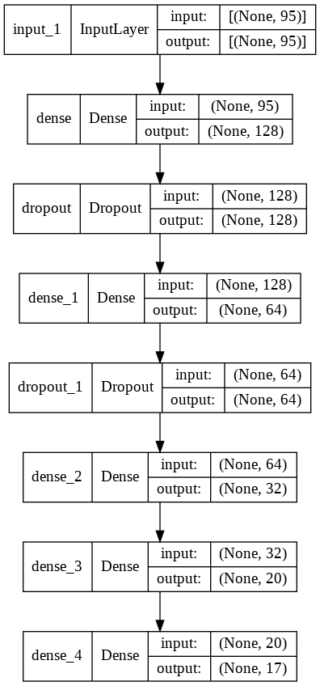

```python
In = Input(shape=(95,))
L1 = Dense(128,activation='relu',
           kernel_initializer=initializers.he_uniform())(In) #https://keras.io/api/layers/initializers/

L1_Drp = Dropout(0.4)(L1)

L2 = Dense(64,activation='relu',
          kernel_initializer=initializers.he_uniform())(L1_Drp)

L2_Drp = Dropout(0.3)(L2)

L3 = Dense(32,activation='relu',
          kernel_initializer=initializers.he_uniform())(L2_Drp)

L4 = Dense(20,activation='relu',
          kernel_initializer=initializers.he_uniform())(L3)

Out = Dense(17,activation='softmax',
           kernel_initializer=initializers.GlorotUniform())(L4)

NeuNet_1 = Model(inputs=In, outputs = Out)

# cce = categorical_crossentropy()
NeuNet_1.compile(loss='categorical_crossentropy', optimizer='SGD', metrics=['accuracy'])

plot_model(NeuNet_1,show_layer_names=True, show_shapes=True)#,to_file='NeuNet_1.png')
```

```python
NeuNet_1.summary()
```

```
Model: "model"
_________________________________________________________________
 Layer (type)                Output Shape              Param #
=================================================================
 input_1 (InputLayer)        [(None, 95)]              0

 dense (Dense)               (None, 128)               12288

 dropout (Dropout)           (None, 128)               0

 dense_1 (Dense)             (None, 64)                8256

 dropout_1 (Dropout)         (None, 64)                0

 dense_2 (Dense)             (None, 32)                2080

 dense_3 (Dense)             (None, 20)                660

 dense_4 (Dense)             (None, 17)                357

=================================================================
Total params: 23,641
Trainable params: 23,641
Non-trainable params: 0
_________________________________________________________________
```

###### Model 1 Training

```python
logdir = os.path.join("logs", datetime.now().strftime("%Y%m%d-%H%M%S"))
print(datetime.now().strftime("%Y%m%d-%H%M%S"))
file_writer = tf.summary.create_file_writer(logdir + "/metrics")
# tensorboard = TensorBoard(log_dir=logdir)
tensorboard = TensorBoard(log_dir=logdir, histogram_freq=1, write_graph=True,write_grads=True)

metric_calc_1 = metric_calc()

# Saving model at every epoch if validation accuracy is improved from previous epoch
filepath_m1="model1_save/weights-{epoch:02d}-{val_accuracy:.4f}.hdf5"
checkpoint_m1 = ModelCheckpoint(filepath=filepath_m1, monitor='val_accuracy',  verbose=1,
                                save_best_only=True,
                                mode='auto')
earlystop_m1 = EarlyStopping(monitor='val_accuracy', min_delta=0.01, patience=20, verbose=1)
reduce_lr_m1 = ReduceLROnPlateau(monitor='val_loss', factor=0.9, patience=2, min_lr=0.001)

callback_list_1 = [metric_calc_1,
                   checkpoint_m1,
                   earlystop_m1,
                   reduce_lr_m1,
                   tensorboard]
# fit network
verbose_1, epochs_1, batch_size_1 = 1, 100, 10
start = time.time()
history_1 = NeuNet_1.fit(X_train_std, y_ctg_train,
                         class_weight = class_wts,
                         validation_data=(X_test_std,y_ctg_test),
                         epochs=epochs_1,
                         batch_size=batch_size_1,
                         verbose=verbose_1,
                         callbacks=callback_list_1)

# Passing the F1 score data of each epoch to tensor board
# https://stackoverflow.com/questions/58102016/how-visualize-in-tensorboard-a-metric-callback
for i in range(len(metric_calc_1.metrics['micro_F1_train'])):
    with file_writer.as_default(step=i+1):
        tf.summary.scalar('micro_F1_train', metric_calc_1.metrics['micro_F1_train'][i])
file_writer.flush()

for i in range(len(metric_calc_1.metrics['micro_F1_val'])):
    with file_writer.as_default(step=i+1):
        tf.summary.scalar('micro_F1_val', metric_calc_1.metrics['micro_F1_val'][i])
file_writer.flush()

stop = time.time()
print('Time Taken for training (sec): ',stop-start)
```

```
20220131-120445
WARNING:tensorflow:`write_grads` will be ignored in TensorFlow 2.0 for the `TensorBoard` Callback.
WARNING:tensorflow:Callback method `on_train_batch_end` is slow compared to the batch time (batch time: 0.0042s vs `on_train_batch_end` time: 0.0190s). Check your callbacks.

micro_F1_train:  0.029421757151593394

micro_F1_val:  0.03138871274571972

Epoch 00001: val_accuracy improved from -inf to 0.03139, saving model to model1_save/weights-01-0.0314.hdf5

micro_F1_train:  0.03981789766936196

micro_F1_val:  0.040424857324032976

Epoch 00002: val_accuracy improved from 0.03139 to 0.04042, saving model to model1_save/weights-02-0.0404.hdf5

micro_F1_train:  0.0485832710470884

micro_F1_val:  0.04787571337983513

Epoch 00003: val_accuracy improved from 0.04042 to 0.04788, saving model to model1_save/weights-03-0.0479.hdf5

micro_F1_train:  0.05415505877556567

micro_F1_val:  0.05294863665187064

Epoch 00004: val_accuracy improved from 0.04788 to 0.05295, saving model to model1_save/weights-04-0.0529.hdf5

micro_F1_train:  0.05809607936400082

micro_F1_val:  0.056753329105897275

Epoch 00005: val_accuracy improved from 0.05295 to 0.05675, saving model to model1_save/weights-05-0.0568.hdf5

micro_F1_train:  0.06047428144322892

micro_F1_val:  0.059606848446417254

Epoch 00006: val_accuracy improved from 0.05675 to 0.05961, saving model to model1_save/weights-06-0.0596.hdf5

```

[output cut: 549 more lines]

```

Epoch 00098: val_accuracy did not improve from 0.21497

micro_F1_train:  0.21193177957464157

micro_F1_val:  0.2098922003804692

Epoch 00099: val_accuracy did not improve from 0.21497

micro_F1_train:  0.21458177617721003

micro_F1_val:  0.215282181357007

Epoch 00100: val_accuracy improved from 0.21497 to 0.21528, saving model to model1_save/weights-100-0.2153.hdf5
Time Taken for training (sec):  1120.963470697403
```

```python
# http://localhost:6006/
%load_ext tensorboard
%tensorboard --logdir logs --host localhost
```

```
The tensorboard extension is already loaded. To reload it, use:
  %reload_ext tensorboard
```

```
Reusing TensorBoard on port 6006 (pid 2268), started 0:22:00 ago. (Use '!kill 2268' to kill it.)
```

###### Model 1 Predictions

```python
NeuNet_1.load_weights("/content/m1_weights-97-0.2150.hdf5")
```

```python
px_data_std = pd.DataFrame(Scaler.transform(px_data))
px_data_std = px_data_std.drop(feature_correlated,axis=1)
```

```python
y_pred_1 = NeuNet_1.predict(px_data_std)
```

```python
np.argmax(y_pred_1,axis=1)
```

```
array([10, 11,  3, ..., 14, 14, 14])
```

```python
y_pred_pd_1 = pd.DataFrame(np.argmax(y_pred_1,axis=1),index=px_data.index)
# y_pred_pd[0] = y_pred_pd[0]+1
```

```python
# y_pred_pd_1
```

```python
y_pred_pd_1.value_counts()
```

```
14    4694
11    3394
15    2198
3     1900
13    1568
10    1436
5     1179
16     865
12     752
4      713
1      694
8      464
2      383
9      347
0      205
7      144
6       89
dtype: int64
```

```python
# px_data.index
```

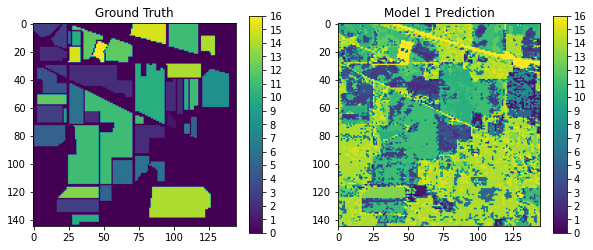

```python
figr,axis = plt.subplots(1,2,figsize=(10,10))
im0 = axis[0].imshow(mat_gt['indian_pines_gt'])#,cmap='jet')
axis[0].set_title('Ground Truth')
plt.colorbar(im0,ax=axis[0],shrink=0.4,aspect=16, ticks=range(0,17,1))

im1 = axis[1].imshow(y_pred_pd_1.to_numpy().reshape((145,145)))#,cmap='jet')
axis[1].set_title('Model 1 Prediction')
plt.colorbar(im1,ax=axis[1],shrink=0.4,aspect=16, ticks=range(0,17,1))
plt.savefig('NeuNet_1_e100.png')
plt.show()
```

##### Observation

Confusion Matrix

```python
y_pred_1_test = NeuNet_1.predict(X_test_std)
y_pred_pd_1_test = pd.DataFrame(np.argmax(y_pred_1_test,axis=1),index=y_test.index)
```

```
Number of misclassified points  78.50348763474952
-------------------------------------------------- Confusion matrix --------------------------------------------------
```

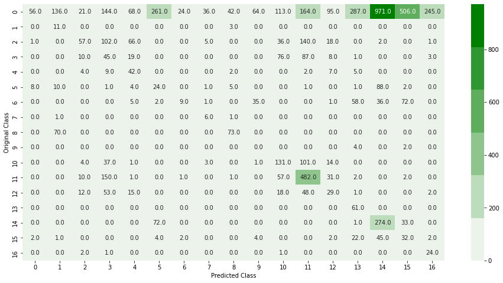

```
-------------------------------------------------- Precision matrix --------------------------------------------------
```

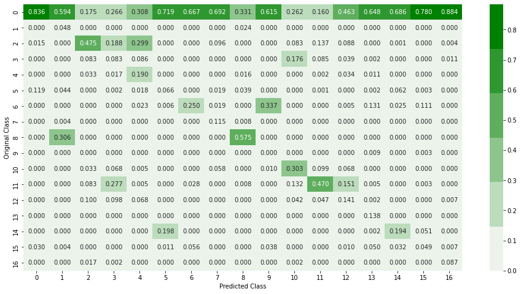

```
Sum of columns in precision matrix [1. 1. 1. 1. 1. 1. 1. 1. 1. 1. 1. 1. 1. 1. 1. 1. 1.]
-------------------------------------------------- Recall matrix --------------------------------------------------
```

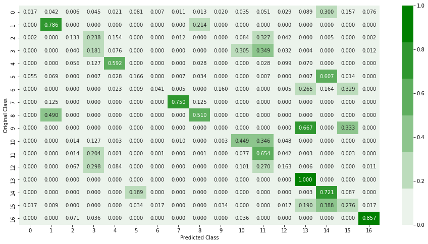

```
Sum of rows in recall matrix [1. 1. 1. 1. 1. 1. 1. 1. 1. 1. 1. 1. 1. 1. 1. 1. 1.]
```

```python
# plot_confusion_matrix(px_class,y_pred_pd_1)
plot_confusion_matrix(y_test,y_pred_pd_1_test)
```

#### 2- Four layered network with relu activation and ADAM optimizer

###### Model 2 Definition

```python
# del NeuNet_2
```

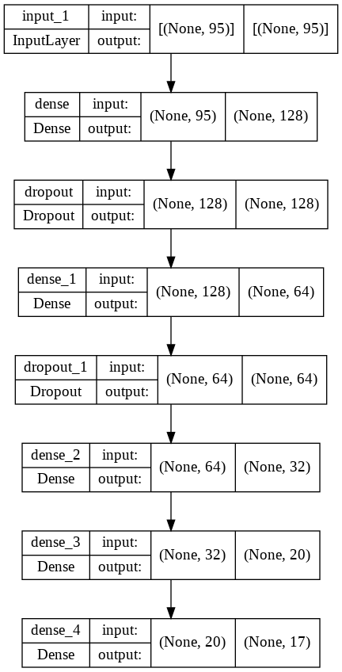

```python
In = Input(shape=(95,))
L1 = Dense(128,activation='relu',
           kernel_initializer=initializers.he_uniform())(In) #https://keras.io/api/layers/initializers/

L1_Drp = Dropout(0.4)(L1)

L2 = Dense(64,activation='relu',
          kernel_initializer=initializers.he_uniform())(L1_Drp)

L2_Drp = Dropout(0.3)(L2)

L3 = Dense(32,activation='relu',
          kernel_initializer=initializers.he_uniform())(L2_Drp)

L4 = Dense(20,activation='relu',
          kernel_initializer=initializers.he_uniform())(L3)

Out = Dense(17,activation='softmax',
           kernel_initializer=initializers.GlorotUniform())(L4)

NeuNet_2 = Model(inputs=In, outputs = Out)

# cce = categorical_crossentropy()
NeuNet_2.compile(loss='categorical_crossentropy', optimizer='Adam', metrics=['accuracy'])

plot_model(NeuNet_2,show_layer_names=True, show_shapes=True)#,to_file='NeuNet_2.png')
```

```python
NeuNet_2.summary()
```

```
Model: "model"
_________________________________________________________________
 Layer (type)                Output Shape              Param #
=================================================================
 input_1 (InputLayer)        [(None, 95)]              0

 dense (Dense)               (None, 128)               12288

 dropout (Dropout)           (None, 128)               0

 dense_1 (Dense)             (None, 64)                8256

 dropout_1 (Dropout)         (None, 64)                0

 dense_2 (Dense)             (None, 32)                2080

 dense_3 (Dense)             (None, 20)                660

 dense_4 (Dense)             (None, 17)                357

=================================================================
Total params: 23,641
Trainable params: 23,641
Non-trainable params: 0
_________________________________________________________________
```

###### Model 2 Training

```python
logdir = os.path.join("logs", datetime.now().strftime("%Y%m%d-%H%M%S"))
print(logdir)
file_writer = tf.summary.create_file_writer(logdir + "/metrics")
# tensorboard = TensorBoard(log_dir=logdir)
tensorboard = TensorBoard(log_dir=logdir, histogram_freq=1, write_graph=True,write_grads=True)

metric_calc_2 = metric_calc()

# Saving model at every epoch if validation accuracy is improved from previous epoch
filepath_m2="model2_save/weights-{epoch:02d}-{val_accuracy:.4f}.hdf5"
checkpoint_m2 = ModelCheckpoint(filepath=filepath_m2, monitor='val_accuracy',  verbose=1,
                                save_best_only=True,
                                mode='auto')
earlystop_m2 = EarlyStopping(monitor='val_accuracy', min_delta=0.01, patience=20, verbose=1)
reduce_lr_m2 = ReduceLROnPlateau(monitor='val_loss', factor=0.9, patience=2, min_lr=0.001)

callback_list_2 = [metric_calc_2,
                   checkpoint_m2,
                   earlystop_m2,
                   reduce_lr_m2,
                   tensorboard]
# fit network
verbose_2, epochs_2, batch_size_2 = 1, 100, 10
start = time.time()
history_2 = NeuNet_2.fit(X_train_std, y_ctg_train,
                         class_weight = class_wts,
                         validation_data=(X_test_std,y_ctg_test),
                         epochs=epochs_2,
                         batch_size=batch_size_2,
                         verbose=verbose_2,
                         callbacks=callback_list_2)

# Passing the F1 score data of each epoch to tensor board
# https://stackoverflow.com/questions/58102016/how-visualize-in-tensorboard-a-metric-callback
for i in range(len(metric_calc_2.metrics['micro_F1_train'])):
    with file_writer.as_default(step=i+1):
        tf.summary.scalar('micro_F1_train', metric_calc_2.metrics['micro_F1_train'][i])
file_writer.flush()

for i in range(len(metric_calc_2.metrics['micro_F1_val'])):
    with file_writer.as_default(step=i+1):
        tf.summary.scalar('micro_F1_val', metric_calc_2.metrics['micro_F1_val'][i])
file_writer.flush()

stop = time.time()
print('Time Taken for training (sec): ',stop-start)
```

```
logs/20220131-122955
WARNING:tensorflow:`write_grads` will be ignored in TensorFlow 2.0 for the `TensorBoard` Callback.
WARNING:tensorflow:Callback method `on_train_batch_end` is slow compared to the batch time (batch time: 0.0045s vs `on_train_batch_end` time: 0.0195s). Check your callbacks.

micro_F1_train:  0.23754841339947

micro_F1_val:  0.2382688649334179

Epoch 00001: val_accuracy improved from -inf to 0.23827, saving model to model2_save/weights-01-0.2383.hdf5

micro_F1_train:  0.2711829856628389

micro_F1_val:  0.27060875079264424

Epoch 00002: val_accuracy improved from 0.23827 to 0.27061, saving model to model2_save/weights-02-0.2706.hdf5

micro_F1_train:  0.24454712237548412

micro_F1_val:  0.24381737476220672

Epoch 00003: val_accuracy did not improve from 0.27061

micro_F1_train:  0.2746483658354284

micro_F1_val:  0.27869372225745087

Epoch 00004: val_accuracy improved from 0.27061 to 0.27869, saving model to model2_save/weights-04-0.2787.hdf5

micro_F1_train:  0.2765509274988109

micro_F1_val:  0.2710843373493976

Epoch 00005: val_accuracy did not improve from 0.27869

micro_F1_train:  0.28348168784398997

micro_F1_val:  0.28233988585922637

Epoch 00006: val_accuracy improved from 0.27869 to 0.28234, saving model to model2_save/weights-06-0.2823.hdf5

```

[output cut: 460 more lines]

```
Epoch 00083: val_accuracy did not improve from 0.49366

micro_F1_train:  0.44513148060066593

micro_F1_val:  0.4367469879518072

Epoch 00084: val_accuracy did not improve from 0.49366

micro_F1_train:  0.47108785757966976

micro_F1_val:  0.46496512365250475

Epoch 00085: val_accuracy did not improve from 0.49366
Epoch 00085: early stopping
Time Taken for training (sec):  919.1604928970337
```

```python
# http://localhost:6006/
%load_ext tensorboard
%tensorboard --logdir logs --host localhost
```

```
The tensorboard extension is already loaded. To reload it, use:
  %reload_ext tensorboard
```

```
Reusing TensorBoard on port 6006 (pid 2268), started 0:43:48 ago. (Use '!kill 2268' to kill it.)
```

###### Model 2 Predictions

```python
NeuNet_2.load_weights("/content/m2_weights-65-0.4937.hdf5")
```

```python
y_pred_2 = NeuNet_2.predict(px_data_std)
```

```python
np.argmax(y_pred_2,axis=1)
```

```
array([ 3,  3,  3, ..., 14, 14, 14])
```

```python
y_pred_pd_2 = pd.DataFrame(np.argmax(y_pred_2,axis=1),index=px_data.index)
# y_pred_pd[0] = y_pred_pd[0]+1
```

```python
# y_pred_pd_2
```

```python
y_pred_pd_2.value_counts()
```

```
14    3795
0     2726
11    2244
15    2170
2     1747
10    1594
12    1408
6     1347
5      945
3      794
4      766
8      691
13     292
16     247
7      103
1       82
9       74
dtype: int64
```

```python
# px_data.index
```

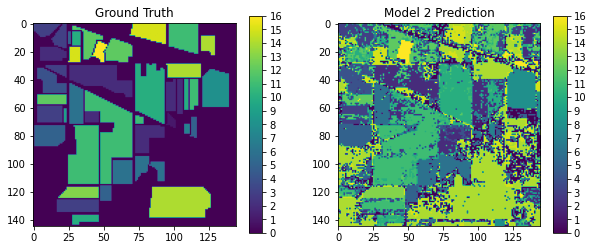

```python
figr,axis = plt.subplots(1,2,figsize=(10,10))
im0 = axis[0].imshow(mat_gt['indian_pines_gt'])#,cmap='jet')
axis[0].set_title('Ground Truth')
plt.colorbar(im0,ax=axis[0],shrink=0.4,aspect=16, ticks=range(0,17,1))

im1 = axis[1].imshow(y_pred_pd_2.to_numpy().reshape((145,145)))#,cmap='jet')
axis[1].set_title('Model 2 Prediction')
plt.colorbar(im1,ax=axis[1],shrink=0.4,aspect=16, ticks=range(0,17,1))
plt.savefig('NeuNet_2_e100.png')
plt.show()
```

##### Observation

```python
y_pred_2_test = NeuNet_2.predict(X_test_std)
y_pred_pd_2_test = pd.DataFrame(np.argmax(y_pred_2_test,axis=1),index=y_test.index)
```

```
Number of misclassified points  50.634115409004444
-------------------------------------------------- Confusion matrix --------------------------------------------------
```

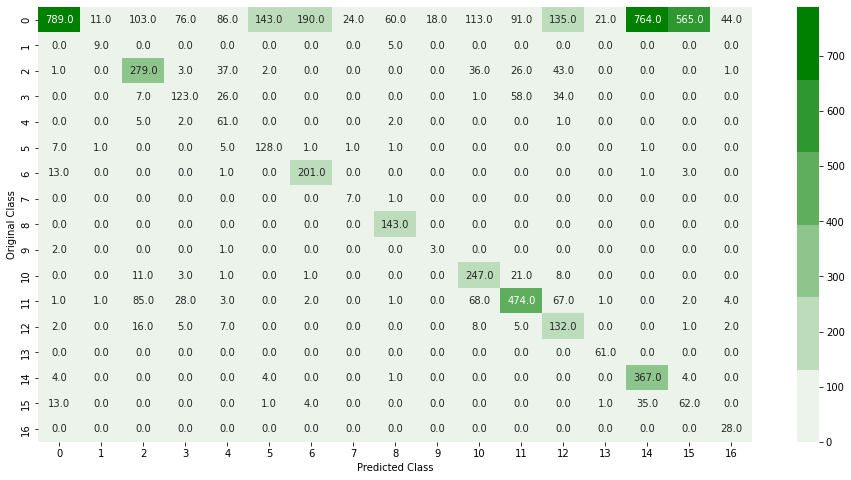

```
-------------------------------------------------- Precision matrix --------------------------------------------------
```

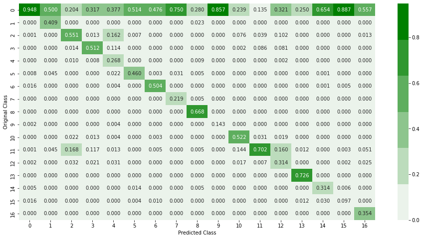

```
Sum of columns in precision matrix [1. 1. 1. 1. 1. 1. 1. 1. 1. 1. 1. 1. 1. 1. 1. 1. 1.]
-------------------------------------------------- Recall matrix --------------------------------------------------
```

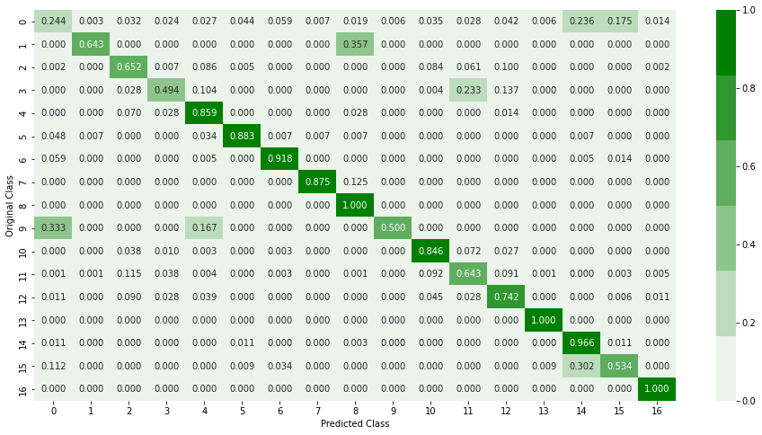

```
Sum of rows in recall matrix [1. 1. 1. 1. 1. 1. 1. 1. 1. 1. 1. 1. 1. 1. 1. 1. 1.]
```

```python
# plot_confusion_matrix(px_class,y_pred_pd_2)
plot_confusion_matrix(y_test,y_pred_pd_2_test)
```

- From Recall matrix we can see that most of the classes have been predicted with high recall.
- Precisions are low for most classes except for class 'zero'.
- From precision matrix (first row), we observe that model finds there are similarity among class 'zero' and other classes.

#### 3- Four layered network with tanh activation and SGD optimizer

###### Model 3 Definition

```python
# del NeuNet_3
```

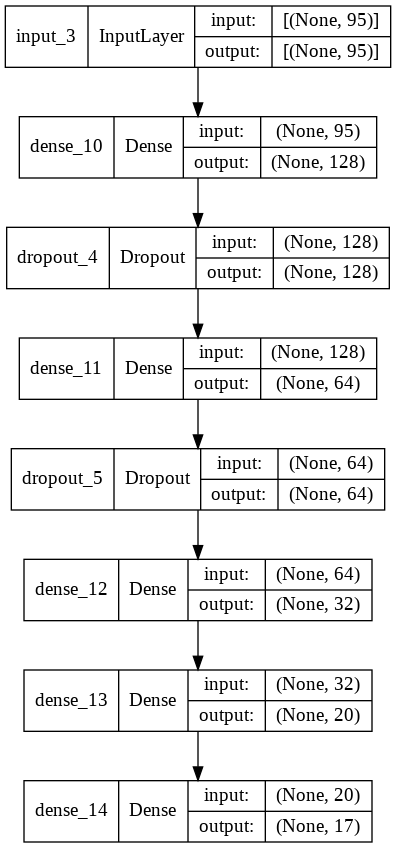

```python
In = Input(shape=(95,))
L1 = Dense(128,activation='tanh',
           kernel_initializer=initializers.he_uniform())(In) #https://keras.io/api/layers/initializers/

L1_Drp = Dropout(0.4)(L1)

L2 = Dense(64,activation='tanh',
          kernel_initializer=initializers.he_uniform())(L1_Drp)

L2_Drp = Dropout(0.3)(L2)

L3 = Dense(32,activation='tanh',
          kernel_initializer=initializers.he_uniform())(L2_Drp)

L4 = Dense(20,activation='tanh',
          kernel_initializer=initializers.he_uniform())(L3)

Out = Dense(17,activation='softmax',
           kernel_initializer=initializers.GlorotUniform())(L4)

NeuNet_3 = Model(inputs=In, outputs = Out)

# cce = categorical_crossentropy()
NeuNet_3.compile(loss='categorical_crossentropy', optimizer='SGD', metrics=['accuracy'])

plot_model(NeuNet_3,show_layer_names=True, show_shapes=True)#,to_file='NeuNet_3.png')
```

```python
NeuNet_3.summary()
```

```
Model: "model_2"
_________________________________________________________________
 Layer (type)                Output Shape              Param #
=================================================================
 input_3 (InputLayer)        [(None, 95)]              0

 dense_10 (Dense)            (None, 128)               12288

 dropout_4 (Dropout)         (None, 128)               0

 dense_11 (Dense)            (None, 64)                8256

 dropout_5 (Dropout)         (None, 64)                0

 dense_12 (Dense)            (None, 32)                2080

 dense_13 (Dense)            (None, 20)                660

 dense_14 (Dense)            (None, 17)                357

=================================================================
Total params: 23,641
Trainable params: 23,641
Non-trainable params: 0
_________________________________________________________________
```

###### Model 3 Training

```python
logdir = os.path.join("logs", datetime.now().strftime("%Y%m%d-%H%M%S"))
print(logdir)
file_writer = tf.summary.create_file_writer(logdir + "/metrics")
# tensorboard = TensorBoard(log_dir=logdir)
tensorboard = TensorBoard(log_dir=logdir, histogram_freq=1, write_graph=True,write_grads=True)

metric_calc_3 = metric_calc()

# Saving model at every epoch if validation accuracy is improved from previous epoch
filepath_m3="model3_save/weights-{epoch:02d}-{val_accuracy:.4f}.hdf5"
checkpoint_m3 = ModelCheckpoint(filepath=filepath_m3, monitor='val_accuracy',  verbose=1,
                                save_best_only=True,
                                mode='auto')
earlystop_m3 = EarlyStopping(monitor='val_accuracy', min_delta=0.01, patience=20, verbose=1)
reduce_lr_m3 = ReduceLROnPlateau(monitor='val_loss', factor=0.9, patience=2, min_lr=0.001)

callback_list_3 = [metric_calc_3,
                   checkpoint_m3,
                   earlystop_m3,
                   reduce_lr_m3,
                   tensorboard]
# fit network
verbose_3, epochs_3, batch_size_3 = 1, 100, 10
start = time.time()
history_3 = NeuNet_3.fit(X_train_std, y_ctg_train,
                         class_weight = class_wts,
                         validation_data=(X_test_std,y_ctg_test),
                         epochs=epochs_3,
                         batch_size=batch_size_3,
                         verbose=verbose_3,
                         callbacks=callback_list_3)

# Passing the F1 score data of each epoch to tensor board
# https://stackoverflow.com/questions/58102016/how-visualize-in-tensorboard-a-metric-callback
for i in range(len(metric_calc_3.metrics['micro_F1_train'])):
    with file_writer.as_default(step=i+1):
        tf.summary.scalar('micro_F1_train', metric_calc_3.metrics['micro_F1_train'][i])
file_writer.flush ()

for i in range(len(metric_calc_3.metrics['micro_F1_val'])):
    with file_writer.as_default(step=i+1):
        tf.summary.scalar('micro_F1_val', metric_calc_3.metrics['micro_F1_val'][i])
file_writer.flush ()

stop = time.time()
print('Time Taken for training (sec): ',stop-start)
```

```
logs/20220131-130044
WARNING:tensorflow:`write_grads` will be ignored in TensorFlow 2.0 for the `TensorBoard` Callback.
WARNING:tensorflow:Callback method `on_train_batch_end` is slow compared to the batch time (batch time: 0.0041s vs `on_train_batch_end` time: 0.0171s). Check your callbacks.

micro_F1_train:  0.05802813073316573

micro_F1_val:  0.060875079264426125

Epoch 00001: val_accuracy improved from -inf to 0.06088, saving model to model3_save/weights-01-0.0609.hdf5

micro_F1_train:  0.06427940476999389

micro_F1_val:  0.06800887761572606

Epoch 00002: val_accuracy improved from 0.06088 to 0.06801, saving model to model3_save/weights-02-0.0680.hdf5

micro_F1_train:  0.0713460623768431

micro_F1_val:  0.07688649334178821

Epoch 00003: val_accuracy improved from 0.06801 to 0.07689, saving model to model3_save/weights-03-0.0769.hdf5

micro_F1_train:  0.07725759325949583

micro_F1_val:  0.08608116677235257

Epoch 00004: val_accuracy improved from 0.07689 to 0.08608, saving model to model3_save/weights-04-0.0861.hdf5

micro_F1_train:  0.08330502140381871

micro_F1_val:  0.0911540900443881

Epoch 00005: val_accuracy improved from 0.08608 to 0.09115, saving model to model3_save/weights-05-0.0912.hdf5

micro_F1_train:  0.0881973228239451

micro_F1_val:  0.09559289790741915

Epoch 00006: val_accuracy improved from 0.09115 to 0.09559, saving model to model3_save/weights-06-0.0956.hdf5

```

[output cut: 328 more lines]

```
Epoch 00061: val_accuracy improved from 0.20101 to 0.20117, saving model to model3_save/weights-61-0.2012.hdf5

micro_F1_train:  0.19623564585173608

micro_F1_val:  0.2010145846544071

Epoch 00062: val_accuracy did not improve from 0.20117

micro_F1_train:  0.19589590269756063

micro_F1_val:  0.20196575776791376

Epoch 00063: val_accuracy improved from 0.20117 to 0.20197, saving model to model3_save/weights-63-0.2020.hdf5
Epoch 00063: early stopping
Time Taken for training (sec):  629.2495293617249
```

```python
# http://localhost:6006/
%load_ext tensorboard
%tensorboard --logdir logs --host localhost
```

```
The tensorboard extension is already loaded. To reload it, use:
  %reload_ext tensorboard
```

```
Reusing TensorBoard on port 6006 (pid 2268), started 1:51:16 ago. (Use '!kill 2268' to kill it.)
```

###### Model 3 Predictions

```python
NeuNet_3.load_weights("/content/m3_weights-63-0.2020.hdf5")
```

```python
y_pred_3 = NeuNet_3.predict(px_data_std)
```

```python
np.argmax(y_pred_3,axis=1)
```

```
array([10, 11, 11, ..., 14, 14, 14])
```

```python
y_pred_pd_3 = pd.DataFrame(np.argmax(y_pred_3,axis=1),index=px_data.index)
# y_pred_pd[0] = y_pred_pd[0]+1
```

```python
# y_pred_pd_3
```

```python
y_pred_pd_3.value_counts()
```

```
14    4500
11    3797
10    2370
15    2099
6     1585
12    1151
9     1028
16     882
13     778
1      577
7      532
4      504
8      462
3      435
2      263
5       62
dtype: int64
```

```python
# px_data.index
```

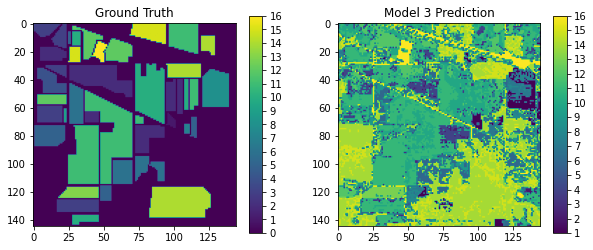

```python
figr,axis = plt.subplots(1,2,figsize=(10,10))
im0 = axis[0].imshow(mat_gt['indian_pines_gt'])#,cmap='jet')
axis[0].set_title('Ground Truth')
plt.colorbar(im0,ax=axis[0],shrink=0.4,aspect=16, ticks=range(0,17,1))

im1 = axis[1].imshow(y_pred_pd_3.to_numpy().reshape((145,145)))#,cmap='jet')
axis[1].set_title('Model 3 Prediction')
plt.colorbar(im1,ax=axis[1],shrink=0.4,aspect=16, ticks=range(0,17,1))
plt.savefig('NeuNet_3_e100.png')
plt.show()
```

##### Observation

```python
y_pred_3_test = NeuNet_3.predict(X_test_std)
y_pred_pd_3_test = pd.DataFrame(np.argmax(y_pred_3_test,axis=1),index=y_test.index)
```

```
Number of misclassified points  79.80342422320862
-------------------------------------------------- Confusion matrix --------------------------------------------------
```

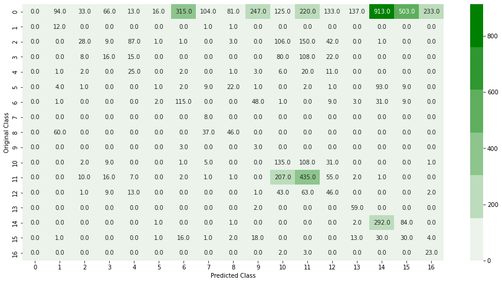

```
-------------------------------------------------- Precision matrix --------------------------------------------------
```

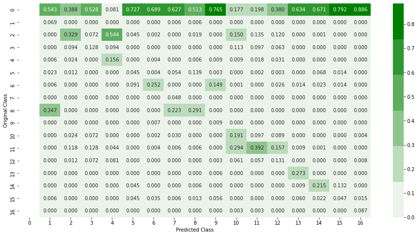

```
Sum of columns in precision matrix [nan  1.  1.  1.  1.  1.  1.  1.  1.  1.  1.  1.  1.  1.  1.  1.  1.]
-------------------------------------------------- Recall matrix --------------------------------------------------
```

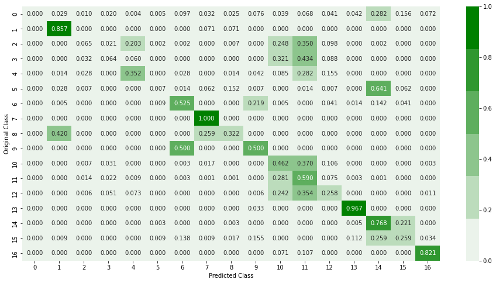

```
Sum of rows in recall matrix [1. 1. 1. 1. 1. 1. 1. 1. 1. 1. 1. 1. 1. 1. 1. 1. 1.]
```

```python
# plot_confusion_matrix(px_class,y_pred_pd_3)
plot_confusion_matrix(y_test,y_pred_pd_3_test)
```

Model is not able to predict regions of class 'zero'. pixels of class 'zero' are classified into different class

#### 4- Four layered network with tanh activation and Adam optimizer

###### Model 4 Definition

```python
# del NeuNet_4
```

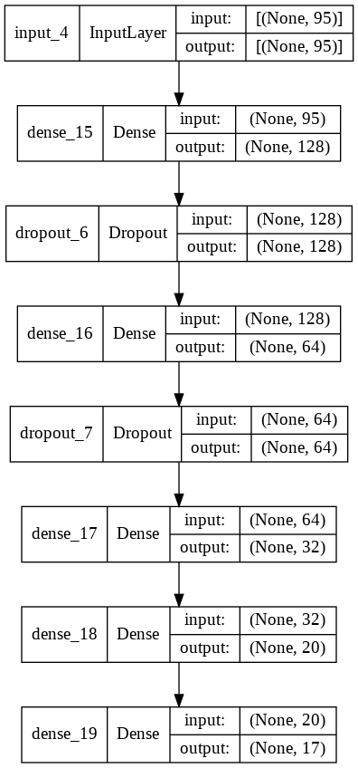

```python
In = Input(shape=(95,))
L1 = Dense(128,activation='tanh',
           kernel_initializer=initializers.he_uniform())(In) #https://keras.io/api/layers/initializers/

L1_Drp = Dropout(0.4)(L1)

L2 = Dense(64,activation='tanh',
          kernel_initializer=initializers.he_uniform())(L1_Drp)

L2_Drp = Dropout(0.3)(L2)

L3 = Dense(32,activation='tanh',
          kernel_initializer=initializers.he_uniform())(L2_Drp)

L4 = Dense(20,activation='tanh',
          kernel_initializer=initializers.he_uniform())(L3)

Out = Dense(17,activation='softmax',
           kernel_initializer=initializers.GlorotUniform())(L4)

NeuNet_4 = Model(inputs=In, outputs = Out)

# cce = categorical_crossentropy()
NeuNet_4.compile(loss='categorical_crossentropy', optimizer='Adam', metrics=['accuracy'])

plot_model(NeuNet_4,show_layer_names=True, show_shapes=True)#,to_file='NeuNet_4.png')
```

```python
NeuNet_4.summary()
```

```
Model: "model_3"
_________________________________________________________________
 Layer (type)                Output Shape              Param #
=================================================================
 input_4 (InputLayer)        [(None, 95)]              0

 dense_15 (Dense)            (None, 128)               12288

 dropout_6 (Dropout)         (None, 128)               0

 dense_16 (Dense)            (None, 64)                8256

 dropout_7 (Dropout)         (None, 64)                0

 dense_17 (Dense)            (None, 32)                2080

 dense_18 (Dense)            (None, 20)                660

 dense_19 (Dense)            (None, 17)                357

=================================================================
Total params: 23,641
Trainable params: 23,641
Non-trainable params: 0
_________________________________________________________________
```

###### Model 4 Training

```python
logdir = os.path.join("logs", datetime.now().strftime("%Y%m%d-%H%M%S"))
print(logdir)
file_writer = tf.summary.create_file_writer(logdir + "/metrics")
# tensorboard = TensorBoard(log_dir=logdir)
tensorboard = TensorBoard(log_dir=logdir, histogram_freq=1, write_graph=True,write_grads=True)

metric_calc_4 = metric_calc()

# Saving model at every epoch if validation accuracy is improved from previous epoch
filepath_m4="model_4_save/weights-{epoch:02d}-{val_accuracy:.4f}.hdf5"
checkpoint_m4 = ModelCheckpoint(filepath=filepath_m4, monitor='val_accuracy',  verbose=1,
                                save_best_only=True,
                                mode='auto')
earlystop_m4 = EarlyStopping(monitor='val_accuracy', min_delta=0.01, patience=20, verbose=1)
reduce_lr_m4 = ReduceLROnPlateau(monitor='val_loss', factor=0.9, patience=2, min_lr=0.001)

callback_list_4 = [metric_calc_4,
                   checkpoint_m4,
                   earlystop_m4,
                   reduce_lr_m4,
                   tensorboard]
# fit network
verbose_4, epochs_4, batch_size_4 = 1, 100, 10
start = time.time()
history_4 = NeuNet_4.fit(X_train_std, y_ctg_train,
                         class_weight = class_wts,
                         validation_data=(X_test_std,y_ctg_test),
                         epochs=epochs_4,
                         batch_size=batch_size_4,
                         verbose=verbose_4,
                         callbacks=callback_list_4)

# Passing the F1 score data of each epoch to tensor board
# https://stackoverflow.com/questions/58102016/how-visualize-in-tensorboard-a-metric-callback
for i in range(len(metric_calc_4.metrics['micro_F1_train'])):
    with file_writer.as_default(step=i+1):
        tf.summary.scalar('micro_F1_train', metric_calc_4.metrics['micro_F1_train'][i])
file_writer.flush ()

for i in range(len(metric_calc_4.metrics['micro_F1_val'])):
    with file_writer.as_default(step=i+1):
        tf.summary.scalar('micro_F1_val', metric_calc_4.metrics['micro_F1_val'][i])
file_writer.flush ()

stop = time.time()
print('Time Taken for training (sec): ',stop-start)
```

```
logs/20220131-132844
WARNING:tensorflow:`write_grads` will be ignored in TensorFlow 2.0 for the `TensorBoard` Callback.
WARNING:tensorflow:Callback method `on_train_batch_end` is slow compared to the batch time (batch time: 0.0036s vs `on_train_batch_end` time: 0.0182s). Check your callbacks.

micro_F1_train:  0.21845484813481006

micro_F1_val:  0.21623335447051364

Epoch 00001: val_accuracy improved from -inf to 0.21623, saving model to model_4_save/weights-01-0.2162.hdf5

micro_F1_train:  0.1535639056873004

micro_F1_val:  0.1548826886493342

Epoch 00002: val_accuracy did not improve from 0.21623

micro_F1_train:  0.22531765984915403

micro_F1_val:  0.22114774889029803

Epoch 00003: val_accuracy improved from 0.21623 to 0.22115, saving model to model_4_save/weights-03-0.2211.hdf5

micro_F1_train:  0.26160222871509137

micro_F1_val:  0.25586556753329104

Epoch 00004: val_accuracy improved from 0.22115 to 0.25587, saving model to model_4_save/weights-04-0.2559.hdf5

micro_F1_train:  0.2238227899707821

micro_F1_val:  0.22352568167406467

Epoch 00005: val_accuracy did not improve from 0.25587

micro_F1_train:  0.2877624515866005

micro_F1_val:  0.2880469245402663

Epoch 00006: val_accuracy improved from 0.25587 to 0.28805, saving model to model_4_save/weights-06-0.2880.hdf5

```

[output cut: 496 more lines]

```
Epoch 00089: val_accuracy did not improve from 0.47226

micro_F1_train:  0.4608955629544065

micro_F1_val:  0.4445149017121116

Epoch 00090: val_accuracy did not improve from 0.47226

micro_F1_train:  0.48624040225589454

micro_F1_val:  0.47178186429930247

Epoch 00091: val_accuracy did not improve from 0.47226
Epoch 00091: early stopping
Time Taken for training (sec):  927.6565854549408
```

```python
# http://localhost:6006/
%load_ext tensorboard
%tensorboard --logdir logs --host localhost
```

```
The tensorboard extension is already loaded. To reload it, use:
  %reload_ext tensorboard
```

```
Reusing TensorBoard on port 6006 (pid 2268), started 1:51:23 ago. (Use '!kill 2268' to kill it.)
```

###### Model 4 Predictions

```python
NeuNet_4.load_weights("/content/m4_weights-71-0.4723.hdf5")
```

```python
y_pred_4 = NeuNet_4.predict(px_data_std)
```

```python
np.argmax(y_pred_4,axis=1)
```

```
array([ 3,  3,  3, ..., 14, 14, 14])
```

```python
y_pred_pd_4 = pd.DataFrame(np.argmax(y_pred_4,axis=1),index=px_data.index)
# y_pred_pd[0] = y_pred_pd[0]+1
```

```python
# y_pred_pd_4
```

```python
y_pred_pd_4.value_counts()
```

```
14    3583
0     2459
15    2396
11    2357
2     1825
10    1559
6     1341
5     1322
12    1211
3      829
8      648
4      601
13     317
16     248
1      136
7       98
9       95
dtype: int64
```

```python
# px_data.index
```

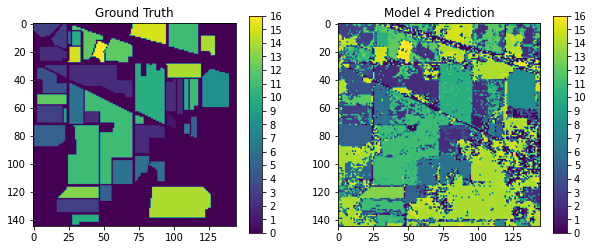

```python
figr,axis = plt.subplots(1,2,figsize=(10,10))
im0 = axis[0].imshow(mat_gt['indian_pines_gt'])#,cmap='jet')
axis[0].set_title('Ground Truth')
plt.colorbar(im0,ax=axis[0],shrink=0.4,aspect=16, ticks=range(0,17,1))

im1 = axis[1].imshow(y_pred_pd_4.to_numpy().reshape((145,145)))#,cmap='jet')
axis[1].set_title('Model 4 Prediction')
plt.colorbar(im1,ax=axis[1],shrink=0.4,aspect=16, ticks=range(0,17,1))
plt.savefig('NeuNet_4_e100.png')
plt.show()
```

##### Observation:

Model prediction better compared to model 1 but fails to predict '0' class

```python
y_pred_4_test = NeuNet_4.predict(X_test_std)
y_pred_pd_4_test = pd.DataFrame(np.argmax(y_pred_4_test,axis=1),index=y_test.index)
```

```
Number of misclassified points  52.774254914394426
-------------------------------------------------- Confusion matrix --------------------------------------------------
```

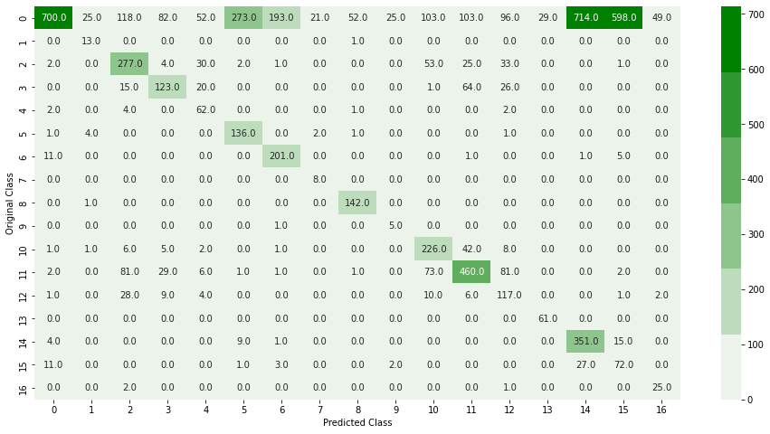

```
-------------------------------------------------- Precision matrix --------------------------------------------------
```

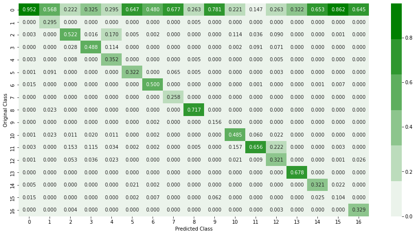

```
Sum of columns in precision matrix [1. 1. 1. 1. 1. 1. 1. 1. 1. 1. 1. 1. 1. 1. 1. 1. 1.]
-------------------------------------------------- Recall matrix --------------------------------------------------
```

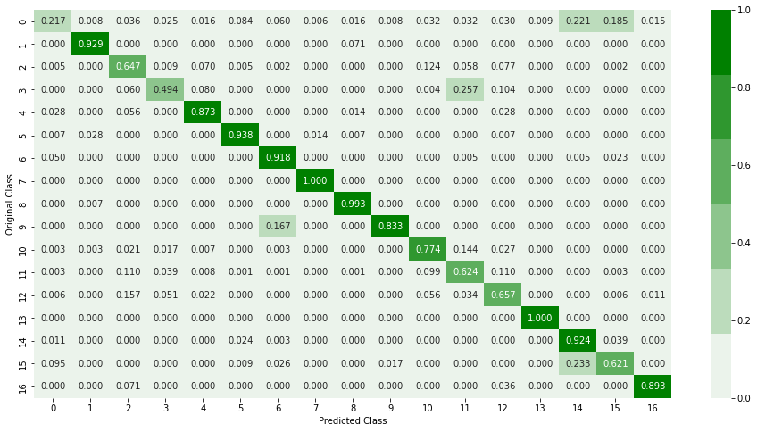

```
Sum of rows in recall matrix [1. 1. 1. 1. 1. 1. 1. 1. 1. 1. 1. 1. 1. 1. 1. 1. 1.]
```

```python
# plot_confusion_matrix(px_class,y_pred_pd_4)
plot_confusion_matrix(y_test,y_pred_pd_4_test)
```

- From Recall matrix we can see that most of the classes have been predicted with high recall.
- Precisions are low for most classes except for class 'zero'.
- From precision matrix (first row), we observe that model finds there are similarity among class 'zero' and other classes.

#### Retrain Model 2

Load saved model weights

##### Retrain 1

```python
# NeuNet_2.load_weights("/content/m2_weights-65-0.4937.hdf5")
```

```python
# opt = optimizers.Adam(learning_rate=0.0009)
# NeuNet_2.compile(loss='categorical_crossentropy', optimizer = opt, metrics=['accuracy'])
```

micro_F1_train: 0.4197866412991778

micro_F1_val: 0.4085288522511097

Epoch 00001: val_accuracy improved from -inf to 0.40853, saving model to model_5_save/weights-e65+01-0.4085.hdf5 1472/1472 [==============================] - 13s 8ms/step - loss: 0.0045 - accuracy: 0.4080 - val_loss: 1.3893 - val_accuracy: 0.4085 - lr: 9.0000e-04 Epoch 2/50 1472/1472 [==============================] - ETA: 0s - loss: 0.0039 - accuracy: 0.4069

micro_F1_train: 0.43833661751715697

micro_F1_val: 0.42057704502219406

Epoch 00002: val_accuracy improved from 0.40853 to 0.42058, saving model to model_5_save/weights-e65+02-0.4206.hdf5 1472/1472 [==============================] - 11s 8ms/step - loss: 0.0039 - accuracy: 0.4069 - val_loss: 1.3481 - val_accuracy: 0.4206 - lr: 9.0000e-04 Epoch 3/50 1469/1472 [============================>.] - ETA: 0s - loss: 0.0043 - accuracy: 0.3920

micro_F1_train: 0.41496228850988653

micro_F1_val: 0.4053582752060875

Epoch 00003: val_accuracy did not improve from 0.42058 1472/1472 [==============================] - 11s 8ms/step - loss: 0.0043 - accuracy: 0.3921 - val_loss: 1.3961 - val_accuracy: 0.4054 - lr: 9.0000e-04 Epoch 4/50 1470/1472 [============================>.] - ETA: 0s - loss: 0.0041 - accuracy: 0.3982

micro_F1_train: 0.404566147992118

micro_F1_val: 0.39267596702599866

Epoch 00004: val_accuracy did not improve from 0.42058 1472/1472 [==============================] - 10s 7ms/step - loss: 0.0041 - accuracy: 0.3981 - val_loss: 1.4385 - val_accuracy: 0.3927 - lr: 9.0000e-04 Epoch 5/50 1472/1472 [==============================] - ETA: 0s - loss: 0.0045 - accuracy: 0.3993

micro_F1_train: 0.4146225453557111

micro_F1_val: 0.4036144578313253

Epoch 00005: val_accuracy did not improve from 0.42058 1472/1472 [==============================] - 12s 8ms/step - loss: 0.0045 - accuracy: 0.3993 - val_loss: 1.4889 - val_accuracy: 0.4036 - lr: 8.1000e-04 Epoch 6/50 1464/1472 [============================>.] - ETA: 0s - loss: 0.0040 - accuracy: 0.4125

micro_F1_train: 0.40612896650132496

micro_F1_val: 0.3979074191502854

Epoch 00006: val_accuracy did not improve from 0.42058 1472/1472 [==============================] - 11s 8ms/step - loss: 0.0040 - accuracy: 0.4127 - val_loss: 1.4660 - val_accuracy: 0.3979 - lr: 8.1000e-04 Epoch 7/50 1463/1472 [============================>.] - ETA: 0s - loss: 0.0042 - accuracy: 0.4053

micro_F1_train: 0.44900455255826593

micro_F1_val: 0.4437222574508561

Epoch 00007: val_accuracy improved from 0.42058 to 0.44372, saving model to model_5_save/weights-e65+07-0.4437.hdf5 1472/1472 [==============================] - 10s 7ms/step - loss: 0.0042 - accuracy: 0.4051 - val_loss: 1.3228 - val_accuracy: 0.4437 - lr: 7.2900e-04 Epoch 8/50 1464/1472 [============================>.] - ETA: 0s - loss: 0.0041 - accuracy: 0.4098

micro_F1_train: 0.46041992253856084

micro_F1_val: 0.45640456563094484

Epoch 00008: val_accuracy improved from 0.44372 to 0.45640, saving model to model_5_save/weights-e65+08-0.4564.hdf5 1472/1472 [==============================] - 11s 7ms/step - loss: 0.0041 - accuracy: 0.4097 - val_loss: 1.2835 - val_accuracy: 0.4564 - lr: 7.2900e-04 Epoch 9/50 1468/1472 [============================>.] - ETA: 0s - loss: 0.0040 - accuracy: 0.4121

micro_F1_train: 0.4449955833389957

micro_F1_val: 0.4376981610653139

Epoch 00009: val_accuracy did not improve from 0.45640 1472/1472 [==============================] - 12s 8ms/step - loss: 0.0040 - accuracy: 0.4120 - val_loss: 1.3431 - val_accuracy: 0.4377 - lr: 7.2900e-04 Epoch 10/50 1466/1472 [============================>.] - ETA: 0s - loss: 0.0038 - accuracy: 0.4199

micro_F1_train: 0.4498878847591221

micro_F1_val: 0.43864933417882057

Epoch 00010: val_accuracy did not improve from 0.45640 1472/1472 [==============================] - 10s 6ms/step - loss: 0.0038 - accuracy: 0.4199 - val_loss: 1.3248 - val_accuracy: 0.4386 - lr: 7.2900e-04 Epoch 11/50 1469/1472 [============================>.] - ETA: 0s - loss: 0.0036 - accuracy: 0.4151

micro_F1_train: 0.43677379900795

micro_F1_val: 0.4231135066582118

Epoch 00011: val_accuracy did not improve from 0.45640 1472/1472 [==============================] - 11s 8ms/step - loss: 0.0036 - accuracy: 0.4154 - val_loss: 1.3184 - val_accuracy: 0.4231 - lr: 6.5610e-04 Epoch 12/50 1464/1472 [============================>.] - ETA: 0s - loss: 0.0039 - accuracy: 0.4049

micro_F1_train: 0.4566147992117959

micro_F1_val: 0.4495878249841471

Epoch 00012: val_accuracy did not improve from 0.45640 1472/1472 [==============================] - 11s 7ms/step - loss: 0.0039 - accuracy: 0.4050 - val_loss: 1.2985 - val_accuracy: 0.4496 - lr: 6.5610e-04 Epoch 13/50 1463/1472 [============================>.] - ETA: 0s - loss: 0.0043 - accuracy: 0.4118

micro_F1_train: 0.4570224909968064

micro_F1_val: 0.44403931515535827

Epoch 00013: val_accuracy did not improve from 0.45640 1472/1472 [==============================] - 11s 7ms/step - loss: 0.0043 - accuracy: 0.4118 - val_loss: 1.3001 - val_accuracy: 0.4440 - lr: 5.9049e-04 Epoch 14/50 1467/1472 [============================>.] - ETA: 0s - loss: 0.0036 - accuracy: 0.4145

micro_F1_train: 0.4394237956105185

micro_F1_val: 0.43024730500951175

Epoch 00014: val_accuracy did not improve from 0.45640 1472/1472 [==============================] - 10s 7ms/step - loss: 0.0036 - accuracy: 0.4146 - val_loss: 1.3110 - val_accuracy: 0.4302 - lr: 5.9049e-04 Epoch 15/50 1463/1472 [============================>.] - ETA: 0s - loss: 0.0045 - accuracy: 0.4161

micro_F1_train: 0.4284161174152341

micro_F1_val: 0.40805326569435635

Epoch 00015: val_accuracy did not improve from 0.45640 1472/1472 [==============================] - 10s 7ms/step - loss: 0.0045 - accuracy: 0.4160 - val_loss: 1.3578 - val_accuracy: 0.4081 - lr: 5.3144e-04 Epoch 16/50 1462/1472 [============================>.] - ETA: 0s - loss: 0.0034 - accuracy: 0.4142

micro_F1_train: 0.43677379900795

micro_F1_val: 0.42422320862396956

Epoch 00016: val_accuracy did not improve from 0.45640 1472/1472 [==============================] - 10s 7ms/step - loss: 0.0034 - accuracy: 0.4144 - val_loss: 1.3229 - val_accuracy: 0.4242 - lr: 5.3144e-04 Epoch 17/50 1465/1472 [============================>.] - ETA: 0s - loss: 0.0036 - accuracy: 0.4107

micro_F1_train: 0.44526737786233606

micro_F1_val: 0.4275523145212429

Epoch 00017: val_accuracy did not improve from 0.45640 1472/1472 [==============================] - 10s 7ms/step - loss: 0.0036 - accuracy: 0.4112 - val_loss: 1.2856 - val_accuracy: 0.4276 - lr: 4.7830e-04 Epoch 18/50 1471/1472 [============================>.] - ETA: 0s - loss: 0.0038 - accuracy: 0.4223

micro_F1_train: 0.4536930080858871

micro_F1_val: 0.4380152187698161

Epoch 00018: val_accuracy did not improve from 0.45640 1472/1472 [==============================] - 11s 7ms/step - loss: 0.0038 - accuracy: 0.4222 - val_loss: 1.2941 - val_accuracy: 0.4380 - lr: 4.7830e-04 Epoch 19/50 1470/1472 [============================>.] - ETA: 0s - loss: 0.0042 - accuracy: 0.4132

micro_F1_train: 0.4732622137663926

micro_F1_val: 0.462428662016487

Epoch 00019: val_accuracy improved from 0.45640 to 0.46243, saving model to model_5_save/weights-e65+19-0.4624.hdf5 1472/1472 [==============================] - 10s 7ms/step - loss: 0.0042 - accuracy: 0.4130 - val_loss: 1.2805 - val_accuracy: 0.4624 - lr: 4.3047e-04 Epoch 20/50 1464/1472 [============================>.] - ETA: 0s - loss: 0.0035 - accuracy: 0.4249

micro_F1_train: 0.44003533328803424

micro_F1_val: 0.4275523145212429

Epoch 00020: val_accuracy did not improve from 0.46243 1472/1472 [==============================] - 11s 7ms/step - loss: 0.0035 - accuracy: 0.4252 - val_loss: 1.3003 - val_accuracy: 0.4276 - lr: 4.3047e-04 Epoch 21/50 1463/1472 [============================>.] - ETA: 0s - loss: 0.0037 - accuracy: 0.4263

micro_F1_train: 0.4439084052456343

micro_F1_val: 0.4329422954977806

Epoch 00021: val_accuracy did not improve from 0.46243 1472/1472 [==============================] - 11s 8ms/step - loss: 0.0037 - accuracy: 0.4262 - val_loss: 1.3088 - val_accuracy: 0.4329 - lr: 4.3047e-04 Epoch 22/50 1461/1472 [============================>.] - ETA: 0s - loss: 0.0033 - accuracy: 0.4255

micro_F1_train: 0.46334171366446963

micro_F1_val: 0.44705136334812934

Epoch 00022: val_accuracy did not improve from 0.46243 1472/1472 [==============================] - 10s 7ms/step - loss: 0.0033 - accuracy: 0.4258 - val_loss: 1.2816 - val_accuracy: 0.4471 - lr: 3.8742e-04 Epoch 23/50 1465/1472 [============================>.] - ETA: 0s - loss: 0.0033 - accuracy: 0.4363

micro_F1_train: 0.43459944282122714

micro_F1_val: 0.42232086239695626

Epoch 00023: val_accuracy did not improve from 0.46243 1472/1472 [==============================] - 11s 7ms/step - loss: 0.0033 - accuracy: 0.4366 - val_loss: 1.3256 - val_accuracy: 0.4223 - lr: 3.8742e-04 Epoch 24/50 1464/1472 [============================>.] - ETA: 0s - loss: 0.0032 - accuracy: 0.4471

micro_F1_train: 0.4411904600122308

micro_F1_val: 0.4272352568167406

Epoch 00024: val_accuracy did not improve from 0.46243 1472/1472 [==============================] - 11s 7ms/step - loss: 0.0032 - accuracy: 0.4473 - val_loss: 1.2703 - val_accuracy: 0.4272 - lr: 3.4868e-04 Epoch 25/50 1472/1472 [==============================] - ETA: 0s - loss: 0.0034 - accuracy: 0.4360

micro_F1_train: 0.42821227152272884

micro_F1_val: 0.4128091312618896

Epoch 00025: val_accuracy did not improve from 0.46243 1472/1472 [==============================] - 11s 7ms/step - loss: 0.0034 - accuracy: 0.4360 - val_loss: 1.3155 - val_accuracy: 0.4128 - lr: 3.4868e-04 Epoch 26/50 1461/1472 [============================>.] - ETA: 0s - loss: 0.0034 - accuracy: 0.4376

micro_F1_train: 0.46103146021607666

micro_F1_val: 0.4497463538363982

Epoch 00026: val_accuracy did not improve from 0.46243 1472/1472 [==============================] - 10s 7ms/step - loss: 0.0034 - accuracy: 0.4370 - val_loss: 1.2471 - val_accuracy: 0.4497 - lr: 3.4868e-04 Epoch 27/50 1464/1472 [============================>.] - ETA: 0s - loss: 0.0033 - accuracy: 0.4445

micro_F1_train: 0.4375891825779711

micro_F1_val: 0.4237476220672162

Epoch 00027: val_accuracy did not improve from 0.46243 1472/1472 [==============================] - 11s 7ms/step - loss: 0.0033 - accuracy: 0.4442 - val_loss: 1.3127 - val_accuracy: 0.4237 - lr: 3.4868e-04 Epoch 28/50 1469/1472 [============================>.] - ETA: 0s - loss: 0.0034 - accuracy: 0.4379

micro_F1_train: 0.46069171706190126

micro_F1_val: 0.4448319594166138

Epoch 00028: val_accuracy did not improve from 0.46243 1472/1472 [==============================] - 12s 8ms/step - loss: 0.0034 - accuracy: 0.4377 - val_loss: 1.2606 - val_accuracy: 0.4448 - lr: 3.4868e-04 Epoch 29/50 1469/1472 [============================>.] - ETA: 0s - loss: 0.0036 - accuracy: 0.4372

micro_F1_train: 0.44710199089488345

micro_F1_val: 0.43389346861128725

Epoch 00029: val_accuracy did not improve from 0.46243 1472/1472 [==============================] - 10s 7ms/step - loss: 0.0037 - accuracy: 0.4372 - val_loss: 1.2936 - val_accuracy: 0.4339 - lr: 3.1381e-04 Epoch 30/50 1463/1472 [============================>.] - ETA: 0s - loss: 0.0033 - accuracy: 0.4435

micro_F1_train: 0.4980634640212

micro_F1_val: 0.48224476854787574

Epoch 00030: val_accuracy improved from 0.46243 to 0.48224, saving model to model_5_save/weights-e65+30-0.4822.hdf5 1472/1472 [==============================] - 10s 7ms/step - loss: 0.0033 - accuracy: 0.4431 - val_loss: 1.2207 - val_accuracy: 0.4822 - lr: 3.1381e-04 Epoch 31/50 1466/1472 [============================>.] - ETA: 0s - loss: 0.0033 - accuracy: 0.4563

micro_F1_train: 0.464360943126996

micro_F1_val: 0.4497463538363982

Epoch 00031: val_accuracy did not improve from 0.48224 1472/1472 [==============================] - 11s 8ms/step - loss: 0.0033 - accuracy: 0.4562 - val_loss: 1.2944 - val_accuracy: 0.4497 - lr: 3.1381e-04 Epoch 32/50 1471/1472 [============================>.] - ETA: 0s - loss: 0.0032 - accuracy: 0.4468

micro_F1_train: 0.46334171366446963

micro_F1_val: 0.45212428662016485

Epoch 00032: val_accuracy did not improve from 0.48224 1472/1472 [==============================] - 11s 7ms/step - loss: 0.0032 - accuracy: 0.4468 - val_loss: 1.2606 - val_accuracy: 0.4521 - lr: 3.1381e-04 Epoch 33/50 1472/1472 [==============================] - ETA: 0s - loss: 0.0031 - accuracy: 0.4446

micro_F1_train: 0.4678942719304206

micro_F1_val: 0.4573557387444515

Epoch 00033: val_accuracy did not improve from 0.48224 1472/1472 [==============================] - 10s 7ms/step - loss: 0.0031 - accuracy: 0.4446 - val_loss: 1.2785 - val_accuracy: 0.4574 - lr: 2.8243e-04 Epoch 34/50 1462/1472 [============================>.] - ETA: 0s - loss: 0.0032 - accuracy: 0.4520

micro_F1_train: 0.4846775837466875

micro_F1_val: 0.47622067216233355

Epoch 00034: val_accuracy did not improve from 0.48224 1472/1472 [==============================] - 11s 7ms/step - loss: 0.0032 - accuracy: 0.4519 - val_loss: 1.2260 - val_accuracy: 0.4762 - lr: 2.8243e-04 Epoch 35/50 1471/1472 [============================>.] - ETA: 0s - loss: 0.0032 - accuracy: 0.4525

micro_F1_train: 0.4687776041312768

micro_F1_val: 0.4560875079264426

Epoch 00035: val_accuracy did not improve from 0.48224 1472/1472 [==============================] - 11s 7ms/step - loss: 0.0032 - accuracy: 0.4526 - val_loss: 1.2522 - val_accuracy: 0.4561 - lr: 2.5419e-04 Epoch 36/50 1472/1472 [==============================] - ETA: 0s - loss: 0.0033 - accuracy: 0.4529

micro_F1_train: 0.4751647754297751

micro_F1_val: 0.4622701331642359

Epoch 00036: val_accuracy did not improve from 0.48224 1472/1472 [==============================] - 11s 8ms/step - loss: 0.0033 - accuracy: 0.4529 - val_loss: 1.2560 - val_accuracy: 0.4623 - lr: 2.5419e-04 Epoch 37/50 1469/1472 [============================>.] - ETA: 0s - loss: 0.0033 - accuracy: 0.4481

micro_F1_train: 0.46809811782292593

micro_F1_val: 0.4530754597336715

Epoch 00037: val_accuracy did not improve from 0.48224 1472/1472 [==============================] - 11s 7ms/step - loss: 0.0033 - accuracy: 0.4482 - val_loss: 1.2611 - val_accuracy: 0.4531 - lr: 2.2877e-04 Epoch 38/50 1466/1472 [============================>.] - ETA: 0s - loss: 0.0033 - accuracy: 0.4502

micro_F1_train: 0.47468913501392945

micro_F1_val: 0.4619530754597337

Epoch 00038: val_accuracy did not improve from 0.48224 1472/1472 [==============================] - 11s 7ms/step - loss: 0.0033 - accuracy: 0.4502 - val_loss: 1.2585 - val_accuracy: 0.4620 - lr: 2.2877e-04 Epoch 39/50 1467/1472 [============================>.] - ETA: 0s - loss: 0.0032 - accuracy: 0.4575

micro_F1_train: 0.4618468437860977

micro_F1_val: 0.4497463538363982

Epoch 00039: val_accuracy did not improve from 0.48224 1472/1472 [==============================] - 15s 10ms/step - loss: 0.0031 - accuracy: 0.4575 - val_loss: 1.2697 - val_accuracy: 0.4497 - lr: 2.0589e-04 Epoch 40/50 1467/1472 [============================>.] - ETA: 0s - loss: 0.0031 - accuracy: 0.4549

micro_F1_train: 0.45790582319766254

micro_F1_val: 0.44419784400760937

Epoch 00040: val_accuracy did not improve from 0.48224 1472/1472 [==============================] - 18s 12ms/step - loss: 0.0031 - accuracy: 0.4551 - val_loss: 1.2853 - val_accuracy: 0.4442 - lr: 2.0589e-04 Epoch 41/50 1466/1472 [============================>.] - ETA: 0s - loss: 0.0032 - accuracy: 0.4499

micro_F1_train: 0.46096351158524157

micro_F1_val: 0.4499048826886493

Epoch 00041: val_accuracy did not improve from 0.48224 1472/1472 [==============================] - 16s 11ms/step - loss: 0.0032 - accuracy: 0.4500 - val_loss: 1.2664 - val_accuracy: 0.4499 - lr: 1.8530e-04 Epoch 42/50 1469/1472 [============================>.] - ETA: 0s - loss: 0.0036 - accuracy: 0.4497

micro_F1_train: 0.44377250798396417

micro_F1_val: 0.42882054533925174

Epoch 00042: val_accuracy did not improve from 0.48224 1472/1472 [==============================] - 10s 7ms/step - loss: 0.0035 - accuracy: 0.4500 - val_loss: 1.3148 - val_accuracy: 0.4288 - lr: 1.8530e-04 Epoch 43/50 1468/1472 [============================>.] - ETA: 0s - loss: 0.0030 - accuracy: 0.4501

micro_F1_train: 0.48515322416253315

micro_F1_val: 0.4722574508560558

Epoch 00043: val_accuracy did not improve from 0.48224 1472/1472 [==============================] - 11s 8ms/step - loss: 0.0030 - accuracy: 0.4506 - val_loss: 1.2288 - val_accuracy: 0.4723 - lr: 1.6677e-04 Epoch 44/50 1463/1472 [============================>.] - ETA: 0s - loss: 0.0031 - accuracy: 0.4596

micro_F1_train: 0.4733301623972277

micro_F1_val: 0.45719720989220036

Epoch 00044: val_accuracy did not improve from 0.48224 1472/1472 [==============================] - 11s 8ms/step - loss: 0.0031 - accuracy: 0.4598 - val_loss: 1.2609 - val_accuracy: 0.4572 - lr: 1.6677e-04 Epoch 45/50 1468/1472 [============================>.] - ETA: 0s - loss: 0.0030 - accuracy: 0.4686

micro_F1_train: 0.47727118298566285

micro_F1_val: 0.46322130627774255

Epoch 00045: val_accuracy did not improve from 0.48224 1472/1472 [==============================] - 11s 8ms/step - loss: 0.0030 - accuracy: 0.4688 - val_loss: 1.2430 - val_accuracy: 0.4632 - lr: 1.5009e-04 Epoch 46/50 1465/1472 [============================>.] - ETA: 0s - loss: 0.0030 - accuracy: 0.4684

micro_F1_train: 0.4992865393762316

micro_F1_val: 0.4833544705136335

Epoch 00046: val_accuracy improved from 0.48224 to 0.48335, saving model to model_5_save/weights-e65+46-0.4834.hdf5 1472/1472 [==============================] - 11s 7ms/step - loss: 0.0030 - accuracy: 0.4683 - val_loss: 1.2139 - val_accuracy: 0.4834 - lr: 1.5009e-04 Epoch 47/50 1464/1472 [============================>.] - ETA: 0s - loss: 0.0030 - accuracy: 0.4742

micro_F1_train: 0.47557246721478563

micro_F1_val: 0.4613189600507292

Epoch 00047: val_accuracy did not improve from 0.48335 1472/1472 [==============================] - 11s 7ms/step - loss: 0.0031 - accuracy: 0.4743 - val_loss: 1.2461 - val_accuracy: 0.4613 - lr: 1.5009e-04 Epoch 48/50 1466/1472 [============================>.] - ETA: 0s - loss: 0.0030 - accuracy: 0.4730

micro_F1_train: 0.4842019433308419

micro_F1_val: 0.47019657577679136

Epoch 00048: val_accuracy did not improve from 0.48335 1472/1472 [==============================] - 12s 8ms/step - loss: 0.0030 - accuracy: 0.4729 - val_loss: 1.2445 - val_accuracy: 0.4702 - lr: 1.5009e-04 Epoch 49/50 1463/1472 [============================>.] - ETA: 0s - loss: 0.0032 - accuracy: 0.4715

micro_F1_train: 0.4725147788272066

micro_F1_val: 0.46163601775523144

Epoch 00049: val_accuracy did not improve from 0.48335 1472/1472 [==============================] - 11s 8ms/step - loss: 0.0032 - accuracy: 0.4716 - val_loss: 1.2702 - val_accuracy: 0.4616 - lr: 1.3509e-04 Epoch 50/50 1466/1472 [============================>.] - ETA: 0s - loss: 0.0032 - accuracy: 0.4704

micro_F1_train: 0.5028198681796562

micro_F1_val: 0.4889029803424223

Epoch 00050: val_accuracy improved from 0.48335 to 0.48890, saving model to model_5_save/weights-e65+50-0.4889.hdf5 1472/1472 [==============================] - 10s 7ms/step - loss: 0.0032 - accuracy: 0.4705 - val_loss: 1.2075 - val_accuracy: 0.4889 - lr: 1.3509e-04 Time Taken for training (sec): 556.2567737102509

##### Retrain 2

```python
NeuNet_2.load_weights("/content/model_5_save/weights-e65+50-0.4889.hdf5")
```

```python
opt = optimizers.Adam(learning_rate=0.0001)
NeuNet_2.compile(loss='categorical_crossentropy', optimizer = opt, metrics=['accuracy'])
```

micro_F1_train: 0.4875314262417612

micro_F1_val: 0.4771718452758402

Epoch 00001: val_accuracy improved from -inf to 0.47717, saving model to model_5_save2/weights-e65+50+01-0.4772.hdf5 1472/1472 [==============================] - 13s 8ms/step - loss: 0.0033 - accuracy: 0.4793 - val_loss: 1.2379 - val_accuracy: 0.4772 Epoch 2/50 1465/1472 [============================>.] - ETA: 0s - loss: 0.0031 - accuracy: 0.4799

micro_F1_train: 0.4989467962220561

micro_F1_val: 0.4843056436271401

Epoch 00002: val_accuracy improved from 0.47717 to 0.48431, saving model to model_5_save2/weights-e65+50+02-0.4843.hdf5 1472/1472 [==============================] - 10s 7ms/step - loss: 0.0031 - accuracy: 0.4801 - val_loss: 1.2088 - val_accuracy: 0.4843 Epoch 3/50 1470/1472 [============================>.] - ETA: 0s - loss: 0.0029 - accuracy: 0.4754

micro_F1_train: 0.49038526873683497

micro_F1_val: 0.4771718452758402

Epoch 00003: val_accuracy did not improve from 0.48431 1472/1472 [==============================] - 10s 7ms/step - loss: 0.0029 - accuracy: 0.4755 - val_loss: 1.2315 - val_accuracy: 0.4772 Epoch 4/50 1464/1472 [============================>.] - ETA: 0s - loss: 0.0032 - accuracy: 0.4707

micro_F1_train: 0.47733913161649794

micro_F1_val: 0.45989220038046924

Epoch 00004: val_accuracy did not improve from 0.48431 1472/1472 [==============================] - 10s 7ms/step - loss: 0.0032 - accuracy: 0.4703 - val_loss: 1.2454 - val_accuracy: 0.4599 Epoch 5/50 1463/1472 [============================>.] - ETA: 0s - loss: 0.0029 - accuracy: 0.4696

micro_F1_train: 0.4914044981993613

micro_F1_val: 0.47479391249207353

Epoch 00005: val_accuracy did not improve from 0.48431 1472/1472 [==============================] - 11s 7ms/step - loss: 0.0029 - accuracy: 0.4701 - val_loss: 1.2199 - val_accuracy: 0.4748 Epoch 6/50 1469/1472 [============================>.] - ETA: 0s - loss: 0.0029 - accuracy: 0.4725

micro_F1_train: 0.4824352789291296

micro_F1_val: 0.46480659480025366

Epoch 00006: val_accuracy did not improve from 0.48431 1472/1472 [==============================] - 11s 7ms/step - loss: 0.0029 - accuracy: 0.4724 - val_loss: 1.2432 - val_accuracy: 0.4648 Epoch 7/50 1470/1472 [============================>.] - ETA: 0s - loss: 0.0029 - accuracy: 0.4752

micro_F1_train: 0.48658014541007

micro_F1_val: 0.47305009511731133

Epoch 00007: val_accuracy did not improve from 0.48431 1472/1472 [==============================] - 11s 7ms/step - loss: 0.0029 - accuracy: 0.4752 - val_loss: 1.2313 - val_accuracy: 0.4731 Epoch 8/50 1461/1472 [============================>.] - ETA: 0s - loss: 0.0031 - accuracy: 0.4645

micro_F1_train: 0.4974519263436842

micro_F1_val: 0.4835129993658846

Epoch 00008: val_accuracy did not improve from 0.48431 1472/1472 [==============================] - 10s 7ms/step - loss: 0.0031 - accuracy: 0.4650 - val_loss: 1.2218 - val_accuracy: 0.4835 Epoch 9/50 1461/1472 [============================>.] - ETA: 0s - loss: 0.0029 - accuracy: 0.4745

micro_F1_train: 0.49058911462934024

micro_F1_val: 0.47463538363982244

Epoch 00009: val_accuracy did not improve from 0.48431 1472/1472 [==============================] - 10s 7ms/step - loss: 0.0029 - accuracy: 0.4743 - val_loss: 1.2405 - val_accuracy: 0.4746 Epoch 10/50 1465/1472 [============================>.] - ETA: 0s - loss: 0.0028 - accuracy: 0.4755

micro_F1_train: 0.48977373105931915

micro_F1_val: 0.4751109701965758

Epoch 00010: val_accuracy did not improve from 0.48431 1472/1472 [==============================] - 10s 7ms/step - loss: 0.0028 - accuracy: 0.4753 - val_loss: 1.2182 - val_accuracy: 0.4751 Epoch 11/50 1472/1472 [==============================] - ETA: 0s - loss: 0.0030 - accuracy: 0.4618

micro_F1_train: 0.4813481008357682

micro_F1_val: 0.4670259987317692

Epoch 00011: val_accuracy did not improve from 0.48431 1472/1472 [==============================] - 11s 8ms/step - loss: 0.0030 - accuracy: 0.4618 - val_loss: 1.2397 - val_accuracy: 0.4670 Epoch 12/50 1470/1472 [============================>.] - ETA: 0s - loss: 0.0029 - accuracy: 0.4756

micro_F1_train: 0.48719168308758576

micro_F1_val: 0.4714648065948003

Epoch 00012: val_accuracy did not improve from 0.48431 1472/1472 [==============================] - 11s 7ms/step - loss: 0.0029 - accuracy: 0.4758 - val_loss: 1.2198 - val_accuracy: 0.4715 Epoch 13/50 1463/1472 [============================>.] - ETA: 0s - loss: 0.0035 - accuracy: 0.4766

micro_F1_train: 0.46932119317795745

micro_F1_val: 0.45339251743817377

Epoch 00013: val_accuracy did not improve from 0.48431 1472/1472 [==============================] - 11s 8ms/step - loss: 0.0035 - accuracy: 0.4767 - val_loss: 1.2638 - val_accuracy: 0.4534 Epoch 14/50 1467/1472 [============================>.] - ETA: 0s - loss: 0.0030 - accuracy: 0.4678

micro_F1_train: 0.4769993884623225

micro_F1_val: 0.4643310082435003

Epoch 00014: val_accuracy did not improve from 0.48431 1472/1472 [==============================] - 11s 8ms/step - loss: 0.0030 - accuracy: 0.4676 - val_loss: 1.2529 - val_accuracy: 0.4643 Epoch 15/50 1464/1472 [============================>.] - ETA: 0s - loss: 0.0028 - accuracy: 0.4771

micro_F1_train: 0.4944621865869403

micro_F1_val: 0.47622067216233355

Epoch 00015: val_accuracy did not improve from 0.48431 1472/1472 [==============================] - 12s 8ms/step - loss: 0.0028 - accuracy: 0.4771 - val_loss: 1.2269 - val_accuracy: 0.4762 Epoch 16/50 1464/1472 [============================>.] - ETA: 0s - loss: 0.0029 - accuracy: 0.4786

micro_F1_train: 0.49228783040021745

micro_F1_val: 0.4776474318325935

Epoch 00016: val_accuracy did not improve from 0.48431 1472/1472 [==============================] - 10s 7ms/step - loss: 0.0029 - accuracy: 0.4788 - val_loss: 1.2216 - val_accuracy: 0.4776 Epoch 17/50 1466/1472 [============================>.] - ETA: 0s - loss: 0.0029 - accuracy: 0.4754

micro_F1_train: 0.4898416796901543

micro_F1_val: 0.4741597970830691

Epoch 00017: val_accuracy did not improve from 0.48431 1472/1472 [==============================] - 13s 9ms/step - loss: 0.0029 - accuracy: 0.4747 - val_loss: 1.2253 - val_accuracy: 0.4742 Epoch 18/50 1461/1472 [============================>.] - ETA: 0s - loss: 0.0032 - accuracy: 0.4829

micro_F1_train: 0.4948698783719508

micro_F1_val: 0.47479391249207353

Epoch 00018: val_accuracy did not improve from 0.48431 1472/1472 [==============================] - 11s 7ms/step - loss: 0.0032 - accuracy: 0.4826 - val_loss: 1.2115 - val_accuracy: 0.4748 Epoch 19/50 1470/1472 [============================>.] - ETA: 0s - loss: 0.0029 - accuracy: 0.4818

micro_F1_train: 0.4982673099137052

micro_F1_val: 0.478281547241598

Epoch 00019: val_accuracy did not improve from 0.48431 1472/1472 [==============================] - 11s 7ms/step - loss: 0.0029 - accuracy: 0.4815 - val_loss: 1.2206 - val_accuracy: 0.4783 Epoch 20/50 1472/1472 [==============================] - ETA: 0s - loss: 0.0028 - accuracy: 0.4784

micro_F1_train: 0.5096826798940002

micro_F1_val: 0.48922003804692454

Epoch 00020: val_accuracy improved from 0.48431 to 0.48922, saving model to model_5_save2/weights-e65+50+20-0.4892.hdf5 1472/1472 [==============================] - 11s 7ms/step - loss: 0.0028 - accuracy: 0.4784 - val_loss: 1.2064 - val_accuracy: 0.4892 Epoch 21/50 1472/1472 [==============================] - ETA: 0s - loss: 0.0028 - accuracy: 0.4839

micro_F1_train: 0.5008493578854386

micro_F1_val: 0.4803424223208624

Epoch 00021: val_accuracy did not improve from 0.48922 1472/1472 [==============================] - 10s 7ms/step - loss: 0.0028 - accuracy: 0.4839 - val_loss: 1.2194 - val_accuracy: 0.4803 Epoch 22/50 1463/1472 [============================>.] - ETA: 0s - loss: 0.0031 - accuracy: 0.4802

micro_F1_train: 0.49276347081606303

micro_F1_val: 0.4733671528218136

Epoch 00022: val_accuracy did not improve from 0.48922 1472/1472 [==============================] - 12s 8ms/step - loss: 0.0031 - accuracy: 0.4805 - val_loss: 1.2210 - val_accuracy: 0.4734 Epoch 23/50 1469/1472 [============================>.] - ETA: 0s - loss: 0.0031 - accuracy: 0.4734

micro_F1_train: 0.49235577903105254

micro_F1_val: 0.47400126823081806

Epoch 00023: val_accuracy did not improve from 0.48922 1472/1472 [==============================] - 11s 7ms/step - loss: 0.0031 - accuracy: 0.4731 - val_loss: 1.2292 - val_accuracy: 0.4740 Epoch 24/50 1465/1472 [============================>.] - ETA: 0s - loss: 0.0030 - accuracy: 0.4756

micro_F1_train: 0.49636474825032273

micro_F1_val: 0.4785986049461002

Epoch 00024: val_accuracy did not improve from 0.48922 1472/1472 [==============================] - 10s 7ms/step - loss: 0.0030 - accuracy: 0.4754 - val_loss: 1.2136 - val_accuracy: 0.4786 Epoch 25/50 1467/1472 [============================>.] - ETA: 0s - loss: 0.0029 - accuracy: 0.4800

micro_F1_train: 0.48868655296595775

micro_F1_val: 0.4724159797083069

Epoch 00025: val_accuracy did not improve from 0.48922 1472/1472 [==============================] - 11s 8ms/step - loss: 0.0029 - accuracy: 0.4801 - val_loss: 1.2261 - val_accuracy: 0.4724 Epoch 26/50 1464/1472 [============================>.] - ETA: 0s - loss: 0.0029 - accuracy: 0.4671

micro_F1_train: 0.5055378134130597

micro_F1_val: 0.48652504755865567

Epoch 00026: val_accuracy did not improve from 0.48922 1472/1472 [==============================] - 12s 8ms/step - loss: 0.0029 - accuracy: 0.4671 - val_loss: 1.1996 - val_accuracy: 0.4865 Epoch 27/50 1463/1472 [============================>.] - ETA: 0s - loss: 0.0028 - accuracy: 0.4819

micro_F1_train: 0.49949038526873685

micro_F1_val: 0.48161065313887125

Epoch 00027: val_accuracy did not improve from 0.48922 1472/1472 [==============================] - 11s 7ms/step - loss: 0.0028 - accuracy: 0.4819 - val_loss: 1.2103 - val_accuracy: 0.4816 Epoch 28/50 1465/1472 [============================>.] - ETA: 0s - loss: 0.0029 - accuracy: 0.4777

micro_F1_train: 0.4991506421145614

micro_F1_val: 0.4784400760938491

Epoch 00028: val_accuracy did not improve from 0.48922 1472/1472 [==============================] - 11s 8ms/step - loss: 0.0029 - accuracy: 0.4781 - val_loss: 1.2118 - val_accuracy: 0.4784 Epoch 29/50 1466/1472 [============================>.] - ETA: 0s - loss: 0.0030 - accuracy: 0.4833

micro_F1_train: 0.507983964123123

micro_F1_val: 0.4881103360811668

Epoch 00029: val_accuracy did not improve from 0.48922 1472/1472 [==============================] - 12s 8ms/step - loss: 0.0030 - accuracy: 0.4837 - val_loss: 1.2035 - val_accuracy: 0.4881 Epoch 30/50 1471/1472 [============================>.] - ETA: 0s - loss: 0.0030 - accuracy: 0.4811

micro_F1_train: 0.5022762791329755

micro_F1_val: 0.48398858592263794

Epoch 00030: val_accuracy did not improve from 0.48922 1472/1472 [==============================] - 11s 7ms/step - loss: 0.0030 - accuracy: 0.4810 - val_loss: 1.2091 - val_accuracy: 0.4840 Epoch 31/50 1472/1472 [==============================] - ETA: 0s - loss: 0.0028 - accuracy: 0.4966

micro_F1_train: 0.5013249983012842

micro_F1_val: 0.48113506658211797

Epoch 00031: val_accuracy did not improve from 0.48922 1472/1472 [==============================] - 11s 8ms/step - loss: 0.0028 - accuracy: 0.4966 - val_loss: 1.2122 - val_accuracy: 0.4811 Epoch 32/50 1471/1472 [============================>.] - ETA: 0s - loss: 0.0029 - accuracy: 0.4772

micro_F1_train: 0.5030916627029965

micro_F1_val: 0.4808180088776157

Epoch 00032: val_accuracy did not improve from 0.48922 1472/1472 [==============================] - 10s 7ms/step - loss: 0.0029 - accuracy: 0.4773 - val_loss: 1.1952 - val_accuracy: 0.4808 Epoch 33/50 1467/1472 [============================>.] - ETA: 0s - loss: 0.0031 - accuracy: 0.4766

micro_F1_train: 0.48630835088672963

micro_F1_val: 0.4678186429930247

Epoch 00033: val_accuracy did not improve from 0.48922 1472/1472 [==============================] - 10s 7ms/step - loss: 0.0031 - accuracy: 0.4771 - val_loss: 1.2345 - val_accuracy: 0.4678 Epoch 34/50 1464/1472 [============================>.] - ETA: 0s - loss: 0.0031 - accuracy: 0.4780

micro_F1_train: 0.4917442413535367

micro_F1_val: 0.4749524413443247

Epoch 00034: val_accuracy did not improve from 0.48922 1472/1472 [==============================] - 10s 7ms/step - loss: 0.0031 - accuracy: 0.4778 - val_loss: 1.2235 - val_accuracy: 0.4750 Epoch 35/50 1465/1472 [============================>.] - ETA: 0s - loss: 0.0028 - accuracy: 0.4810

micro_F1_train: 0.500373717469593

micro_F1_val: 0.4819277108433735

Epoch 00035: val_accuracy did not improve from 0.48922 1472/1472 [==============================] - 11s 7ms/step - loss: 0.0028 - accuracy: 0.4812 - val_loss: 1.2113 - val_accuracy: 0.4819 Epoch 36/50 1465/1472 [============================>.] - ETA: 0s - loss: 0.0029 - accuracy: 0.4898

micro_F1_train: 0.5001019229462527

micro_F1_val: 0.4835129993658846

Epoch 00036: val_accuracy did not improve from 0.48922 1472/1472 [==============================] - 11s 8ms/step - loss: 0.0029 - accuracy: 0.4898 - val_loss: 1.2060 - val_accuracy: 0.4835 Epoch 37/50 1470/1472 [============================>.] - ETA: 0s - loss: 0.0032 - accuracy: 0.4814

micro_F1_train: 0.48963783379764897

micro_F1_val: 0.47130627774254913

Epoch 00037: val_accuracy did not improve from 0.48922 1472/1472 [==============================] - 10s 7ms/step - loss: 0.0032 - accuracy: 0.4813 - val_loss: 1.2346 - val_accuracy: 0.4713 Epoch 38/50 1468/1472 [============================>.] - ETA: 0s - loss: 0.0028 - accuracy: 0.4813

micro_F1_train: 0.4980634640212

micro_F1_val: 0.478281547241598

Epoch 00038: val_accuracy did not improve from 0.48922 1472/1472 [==============================] - 11s 7ms/step - loss: 0.0028 - accuracy: 0.4818 - val_loss: 1.2195 - val_accuracy: 0.4783 Epoch 39/50 1466/1472 [============================>.] - ETA: 0s - loss: 0.0031 - accuracy: 0.4797

micro_F1_train: 0.4828429707141401

micro_F1_val: 0.46591629676601143

Epoch 00039: val_accuracy did not improve from 0.48922 1472/1472 [==============================] - 12s 8ms/step - loss: 0.0031 - accuracy: 0.4794 - val_loss: 1.2459 - val_accuracy: 0.4659 Epoch 40/50 1465/1472 [============================>.] - ETA: 0s - loss: 0.0028 - accuracy: 0.4752

micro_F1_train: 0.491200652306856

micro_F1_val: 0.47463538363982244

Epoch 00040: val_accuracy did not improve from 0.48922 1472/1472 [==============================] - 11s 7ms/step - loss: 0.0028 - accuracy: 0.4752 - val_loss: 1.2134 - val_accuracy: 0.4746 Epoch 41/50 1472/1472 [==============================] - ETA: 0s - loss: 0.0030 - accuracy: 0.4786

micro_F1_train: 0.511109601141537

micro_F1_val: 0.4930247305009512

Epoch 00041: val_accuracy improved from 0.48922 to 0.49302, saving model to model_5_save2/weights-e65+50+41-0.4930.hdf5 1472/1472 [==============================] - 12s 8ms/step - loss: 0.0030 - accuracy: 0.4786 - val_loss: 1.1793 - val_accuracy: 0.4930 Epoch 42/50 1466/1472 [============================>.] - ETA: 0s - loss: 0.0029 - accuracy: 0.4854

micro_F1_train: 0.4992185907453965

micro_F1_val: 0.4755865567533291

Epoch 00042: val_accuracy did not improve from 0.49302 1472/1472 [==============================] - 10s 7ms/step - loss: 0.0029 - accuracy: 0.4853 - val_loss: 1.2086 - val_accuracy: 0.4756 Epoch 43/50 1463/1472 [============================>.] - ETA: 0s - loss: 0.0028 - accuracy: 0.4815

micro_F1_train: 0.5030237140721614

micro_F1_val: 0.4833544705136335

Epoch 00043: val_accuracy did not improve from 0.49302 1472/1472 [==============================] - 10s 7ms/step - loss: 0.0028 - accuracy: 0.4816 - val_loss: 1.1886 - val_accuracy: 0.4834 Epoch 44/50 1461/1472 [============================>.] - ETA: 0s - loss: 0.0028 - accuracy: 0.4875

micro_F1_train: 0.4956173133111368

micro_F1_val: 0.47622067216233355

Epoch 00044: val_accuracy did not improve from 0.49302 1472/1472 [==============================] - 10s 7ms/step - loss: 0.0028 - accuracy: 0.4871 - val_loss: 1.2170 - val_accuracy: 0.4762 Epoch 45/50 1471/1472 [============================>.] - ETA: 0s - loss: 0.0030 - accuracy: 0.4838

micro_F1_train: 0.5017326900862947

micro_F1_val: 0.4862079898541535

Epoch 00045: val_accuracy did not improve from 0.49302 1472/1472 [==============================] - 10s 7ms/step - loss: 0.0030 - accuracy: 0.4839 - val_loss: 1.1929 - val_accuracy: 0.4862 Epoch 46/50 1471/1472 [============================>.] - ETA: 0s - loss: 0.0028 - accuracy: 0.4954

micro_F1_train: 0.4928993680777332

micro_F1_val: 0.4766962587190869

Epoch 00046: val_accuracy did not improve from 0.49302 1472/1472 [==============================] - 11s 8ms/step - loss: 0.0028 - accuracy: 0.4953 - val_loss: 1.2260 - val_accuracy: 0.4767 Epoch 47/50 1470/1472 [============================>.] - ETA: 0s - loss: 0.0029 - accuracy: 0.4816

micro_F1_train: 0.4875993748725963

micro_F1_val: 0.4724159797083069

Epoch 00047: val_accuracy did not improve from 0.49302 1472/1472 [==============================] - 10s 7ms/step - loss: 0.0029 - accuracy: 0.4816 - val_loss: 1.2171 - val_accuracy: 0.4724 Epoch 48/50 1472/1472 [==============================] - ETA: 0s - loss: 0.0029 - accuracy: 0.4822

micro_F1_train: 0.500373717469593

micro_F1_val: 0.4825618262523779

Epoch 00048: val_accuracy did not improve from 0.49302 1472/1472 [==============================] - 10s 7ms/step - loss: 0.0029 - accuracy: 0.4822 - val_loss: 1.1981 - val_accuracy: 0.4826 Epoch 49/50 1470/1472 [============================>.] - ETA: 0s - loss: 0.0029 - accuracy: 0.4899

micro_F1_train: 0.5107019093565265

micro_F1_val: 0.49286620164870004

Epoch 00049: val_accuracy did not improve from 0.49302 1472/1472 [==============================] - 10s 7ms/step - loss: 0.0029 - accuracy: 0.4897 - val_loss: 1.1890 - val_accuracy: 0.4929 Epoch 50/50 1467/1472 [============================>.] - ETA: 0s - loss: 0.0028 - accuracy: 0.4813

micro_F1_train: 0.5160698511924985

micro_F1_val: 0.49603677869372226

Epoch 00050: val_accuracy improved from 0.49302 to 0.49604, saving model to model_5_save2/weights-e65+50+50-0.4960.hdf5 1472/1472 [==============================] - 11s 7ms/step - loss: 0.0028 - accuracy: 0.4816 - val_loss: 1.1668 - val_accuracy: 0.4960 Time Taken for training (sec): 562.9610755443573

##### Retrain 3

```python
NeuNet_2.load_weights("/content/m2_weights-e65+50+50-0.4960.hdf5")
```

```python
opt = optimizers.Adam(learning_rate=0.0001)
NeuNet_2.compile(loss='categorical_crossentropy', optimizer = opt, metrics=['accuracy'])
```

```python
logdir = os.path.join("logs", datetime.now().strftime("%Y%m%d-%H%M%S"))
print(logdir)
file_writer = tf.summary.create_file_writer(logdir + "/metrics")
# tensorboard = TensorBoard(log_dir=logdir)
tensorboard = TensorBoard(log_dir=logdir, histogram_freq=1, write_graph=True,write_grads=True)

metric_calc_5 = metric_calc()

# Saving model at every epoch if validation accuracy is improved from previous epoch
filepath_m5="model_5_save3/weights-e65+50+50+{epoch:02d}-{val_accuracy:.4f}.hdf5"
checkpoint_m5 = ModelCheckpoint(filepath=filepath_m5, monitor='val_accuracy',  verbose=1,
                                save_best_only=True,
                                mode='auto')
# earlystop_m5 = EarlyStopping(monitor='val_accuracy', min_delta=0.01, patience=20, verbose=1)
# reduce_lr_m5 = ReduceLROnPlateau(monitor='val_loss', factor=0.9, patience=2, min_lr=0.0001)

callback_list_5 = [metric_calc_5,
                   checkpoint_m5,
                   #earlystop_m5,
                   #reduce_lr_m5,
                   tensorboard]
# fit network
verbose_5, epochs_5, batch_size_5 = 1, 50, 10
start = time.time()
history_5 = NeuNet_2.fit(X_train_std, y_ctg_train,
                         class_weight = class_wts,
                         validation_data=(X_test_std,y_ctg_test),
                         epochs=epochs_5,
                         batch_size=batch_size_5,
                         verbose=verbose_5,
                         callbacks=callback_list_5)

# Passing the F1 score data of each epoch to tensor board
# https://stackoverflow.com/questions/58102016/how-visualize-in-tensorboard-a-metric-callback
for i in range(len(metric_calc_5.metrics['micro_F1_train'])):
    with file_writer.as_default(step=i+1):
        tf.summary.scalar('micro_F1_train', metric_calc_5.metrics['micro_F1_train'][i])
file_writer.flush()

for i in range(len(metric_calc_5.metrics['micro_F1_val'])):
    with file_writer.as_default(step=i+1):
        tf.summary.scalar('micro_F1_val', metric_calc_5.metrics['micro_F1_val'][i])
file_writer.flush()

stop = time.time()
print('Time Taken for training (sec): ',stop-start)
```

```
logs/20220211-113500
WARNING:tensorflow:`write_grads` will be ignored in TensorFlow 2.0 for the `TensorBoard` Callback.
WARNING:tensorflow:Callback method `on_train_batch_end` is slow compared to the batch time (batch time: 0.0051s vs `on_train_batch_end` time: 0.0182s). Check your callbacks.

micro_F1_train:  0.49582115920364206

micro_F1_val:  0.4819277108433735

Epoch 00001: val_accuracy improved from -inf to 0.48193, saving model to model_5_save3/weights-e65+50+50+01-0.4819.hdf5

micro_F1_train:  0.5053339675205545

micro_F1_val:  0.4903297400126823

Epoch 00002: val_accuracy improved from 0.48193 to 0.49033, saving model to model_5_save3/weights-e65+50+50+02-0.4903.hdf5

micro_F1_train:  0.4980634640212

micro_F1_val:  0.4809765377298668

Epoch 00003: val_accuracy did not improve from 0.49033

micro_F1_train:  0.5104301148331861

micro_F1_val:  0.4906467977171845

Epoch 00004: val_accuracy improved from 0.49033 to 0.49065, saving model to model_5_save3/weights-e65+50+50+04-0.4906.hdf5

micro_F1_train:  0.5033634572263369

micro_F1_val:  0.4836715282181357

Epoch 00005: val_accuracy did not improve from 0.49065

micro_F1_train:  0.5048583271047088

micro_F1_val:  0.48826886493341787

Epoch 00006: val_accuracy did not improve from 0.49065

```

[output cut: 249 more lines]

```

Epoch 00048: val_accuracy did not improve from 0.50317

micro_F1_train:  0.5165454916083441

micro_F1_val:  0.4930247305009512

Epoch 00049: val_accuracy did not improve from 0.50317

micro_F1_train:  0.5219134334443161

micro_F1_val:  0.49698795180722893

Epoch 00050: val_accuracy did not improve from 0.50317
Time Taken for training (sec):  563.025274515152
```

```python
# http://localhost:6006/
%load_ext tensorboard
%tensorboard --logdir logs --host localhost
```